# MEISSEN

# Paso 4: Eliminar duplicados basados en ciertas columnas ('col1', 'col2')

```python
df_sin_duplicados_columnas = df_sin_duplicados.drop_duplicates(subset=['DOCUMENTO', 'FECHA_INGRESO'], keep='last')
df_sin_duplicados_columnas
```

|  | CODIGO_USS | NOMBRE_USS | TIPO_HC | NOMBRE_TIPOHC | INGRESO | FECHA_INGRESO | TIPO_INGRESO | INGRESO_POR | FECHA_ATENCION | AREA | ... | PLAN_BENEFICIOS | ID_MEDICO | NOMBRE_MEDICO | ESPECIALIDAD | DIAGNOSTICO | NOMBRE_DIAGNOSTICO | TIPO_DX | REGISTRO_EGRESO | DIASGNOSTICO_EGRESO | DX_EGRESO |
| --- | --- | --- | --- | --- | --- | --- | --- | --- | --- | --- | --- | --- | --- | --- | --- | --- | --- | --- | --- | --- | --- |
| 7 | ME | HOSPITAL MEISSEN | HCW068 | CONSULTA INICIAL DE URGENCIAS | 16136467 | 2025-04-13 01:10:36.813 | AMBULATORIO | URGENCIAS | 2025-04-13 | B01ME | ... | C00511 | 1010067295 | AVELLANEDA PINZON XIMENA | MEDICINA GENERAL MIXTA | J989 | TRASTORNO RESPIRATORIO, NO ESPECIFICADO ... | PRINCIPAL | NaN |  | NaN |
| 21 | ME | HOSPITAL MEISSEN | HCW089 | CONSULTA INICIAL DE URGENCIAS PEDIATRICA | 16136476 | 2025-04-13 01:55:18.460 | AMBULATORIO | URGENCIAS | 2025-04-13 | B01ME | ... | C00601 | 1000159382 | ROMERO TRIANA ANDERSON CAMILO | MEDICINA GENERAL MIXTA | J050 | LARINGITIS OBSTRUCTIVA, AGUDA [CRUP] ... | PRINCIPAL | NaN |  | NaN |
| 23 | ME | HOSPITAL MEISSEN | HCW089 | CONSULTA INICIAL DE URGENCIAS PEDIATRICA | 16136483 | 2025-04-13 03:08:20.957 | AMBULATORIO | URGENCIAS | 2025-04-13 | B01ME | ... | S06902 | 1007161544 | RUIZ HERNANDEZ JEISON ALEJANDRO | MEDICINA GENERAL MIXTA | J219 | BRONQUIOLITIS AGUDA, NO ESPECIFICADA ... | PRINCIPAL | NaN |  | NaN |
| 37 | ME | HOSPITAL MEISSEN | HCW068 | CONSULTA INICIAL DE URGENCIAS | 16136504 | 2025-04-13 06:26:59.807 | AMBULATORIO | URGENCIAS | 2025-04-13 | B01ME | ... | FES03414 | 1091811125 | GUERRERO ARAQUE LEANDRO JAVIER | MEDICINA GENERAL | J441 | ENFERMEDAD PULMONAR OBSTRUCTIVA CRONICA CON EX... | PRINCIPAL | NaN |  | NaN |
| 62 | ME | HOSPITAL MEISSEN | HCW089 | CONSULTA INICIAL DE URGENCIAS PEDIATRICA | 16136545 | 2025-04-13 08:01:10.533 | AMBULATORIO | URGENCIAS | 2025-04-13 | B01ME | ... | FES03414 | 52384021 | AREVALO VILLAMARIN INGRID TATIANA | MEDICINA GENERAL | J459 | ASMA, NO ESPECIFICADA ... | PRINCIPAL | NaN |  | NaN |
| ... | ... | ... | ... | ... | ... | ... | ... | ... | ... | ... | ... | ... | ... | ... | ... | ... | ... | ... | ... | ... | ... |
| 1901 | ME | HOSPITAL MEISSEN | HCW089 | CONSULTA INICIAL DE URGENCIAS PEDIATRICA | 16152595 | 2025-04-19 21:10:16.987 | AMBULATORIO | URGENCIAS | 2025-04-19 | B01ME | ... | C01705 | 1033798506 | ZAPATA RODRIGUEZ JUAN SEBASTIAN | MEDICINA GENERAL - PROGRAMAS | J00X | RINOFARINGITIS AGUDA (RESFRIADO COMUN) ... | PRINCIPAL | NaN |  | NaN |
| 1905 | ME | HOSPITAL MEISSEN | HCW089 | CONSULTA INICIAL DE URGENCIAS PEDIATRICA | 16152727 | 2025-04-19 22:19:19.900 | AMBULATORIO | URGENCIAS | 2025-04-19 | B01ME | ... | FES03414 | 1033798506 | ZAPATA RODRIGUEZ JUAN SEBASTIAN | MEDICINA GENERAL - PROGRAMAS | J00X | RINOFARINGITIS AGUDA (RESFRIADO COMUN) ... | PRINCIPAL | NaN |  | NaN |
| 1908 | ME | HOSPITAL MEISSEN | HCW068 | CONSULTA INICIAL DE URGENCIAS | 16152759 | 2025-04-19 22:41:59.183 | AMBULATORIO | URGENCIAS | 2025-04-19 | B01ME | ... | FES03414 | 93390482 | BAUTISTA GARCIA JOSE LEONEL | MEDICINA GENERAL | J399 | ENFERMEDAD DE LAS VIAS RESPIRATORIAS SUPERIORE... | PRINCIPAL | NaN |  | NaN |
| 1910 | ME | HOSPITAL MEISSEN | HCW068 | CONSULTA INICIAL DE URGENCIAS | 16152797 | 2025-04-19 22:51:34.403 | AMBULATORIO | URGENCIAS | 2025-04-20 | B01ME | ... | FES03414 | 93390482 | BAUTISTA GARCIA JOSE LEONEL | MEDICINA GENERAL | J441 | ENFERMEDAD PULMONAR OBSTRUCTIVA CRONICA CON EX... | PRINCIPAL | NaN |  | NaN |
| 1913 | ME | HOSPITAL MEISSEN | HCW089 | CONSULTA INICIAL DE URGENCIAS PEDIATRICA | 16152851 | 2025-04-19 23:28:06.063 | HOSPITALARIO | URGENCIAS | 2025-04-20 | B01ME | ... | FES03414 | 1033798506 | ZAPATA RODRIGUEZ JUAN SEBASTIAN | MEDICINA GENERAL - PROGRAMAS | J459 | ASMA, NO ESPECIFICADA ... | PRINCIPAL | NaN |  | NaN |

223 rows × 43 columns

index=False: Evita incluir la columna de índices del DataFrame en el archivo.

```python
df_sin_duplicados_columnas.columns
```

```
Index(['CODIGO_USS', 'NOMBRE_USS', 'TIPO_HC', 'NOMBRE_TIPOHC', 'INGRESO',
       'FECHA_INGRESO', 'TIPO_INGRESO', 'INGRESO_POR', 'FECHA_ATENCION',
       'AREA', 'NOMBRE_AREA', 'TIPO_AREA_SERVICIO', 'AREA_URGENCIAS', 'FOLIO',
       'TIPO_ID', 'DOCUMENTO', 'PRIMER_NOMBRE', 'SEGUNDO_NOMBRE',
       'PRIMER_APELLIDO', 'SEGUNDO_APELLIDO', 'FECHA_NACIMIENTO', 'EDAD',
       'GENERO', 'CODIGO_BARRIO', 'NOMBRE_BARRIO', 'DIRECCION', 'TELEFONO',
       'LOCALIDAD', 'NOMBRE_LOCALIDAD', 'TIPO_PACIENTE', 'TIPO_AFILIADO',
       'TERCERO_ENTIDAD', 'NOMBRE_TERCERO', 'PLAN_BENEFICIOS', 'ID_MEDICO',
       'NOMBRE_MEDICO', 'ESPECIALIDAD', 'DIAGNOSTICO', 'NOMBRE_DIAGNOSTICO',
       'TIPO_DX', 'REGISTRO_EGRESO', 'DIASGNOSTICO_EGRESO', 'DX_EGRESO'],
      dtype='object')
```

```python
df_sin_duplicados_columnas
```

|  | CODIGO_USS | NOMBRE_USS | TIPO_HC | NOMBRE_TIPOHC | INGRESO | FECHA_INGRESO | TIPO_INGRESO | INGRESO_POR | FECHA_ATENCION | AREA | ... | PLAN_BENEFICIOS | ID_MEDICO | NOMBRE_MEDICO | ESPECIALIDAD | DIAGNOSTICO | NOMBRE_DIAGNOSTICO | TIPO_DX | REGISTRO_EGRESO | DIASGNOSTICO_EGRESO | DX_EGRESO |
| --- | --- | --- | --- | --- | --- | --- | --- | --- | --- | --- | --- | --- | --- | --- | --- | --- | --- | --- | --- | --- | --- |
| 7 | ME | HOSPITAL MEISSEN | HCW068 | CONSULTA INICIAL DE URGENCIAS | 16136467 | 2025-04-13 01:10:36.813 | AMBULATORIO | URGENCIAS | 2025-04-13 | B01ME | ... | C00511 | 1010067295 | AVELLANEDA PINZON XIMENA | MEDICINA GENERAL MIXTA | J989 | TRASTORNO RESPIRATORIO, NO ESPECIFICADO ... | PRINCIPAL | NaN |  | NaN |
| 21 | ME | HOSPITAL MEISSEN | HCW089 | CONSULTA INICIAL DE URGENCIAS PEDIATRICA | 16136476 | 2025-04-13 01:55:18.460 | AMBULATORIO | URGENCIAS | 2025-04-13 | B01ME | ... | C00601 | 1000159382 | ROMERO TRIANA ANDERSON CAMILO | MEDICINA GENERAL MIXTA | J050 | LARINGITIS OBSTRUCTIVA, AGUDA [CRUP] ... | PRINCIPAL | NaN |  | NaN |
| 23 | ME | HOSPITAL MEISSEN | HCW089 | CONSULTA INICIAL DE URGENCIAS PEDIATRICA | 16136483 | 2025-04-13 03:08:20.957 | AMBULATORIO | URGENCIAS | 2025-04-13 | B01ME | ... | S06902 | 1007161544 | RUIZ HERNANDEZ JEISON ALEJANDRO | MEDICINA GENERAL MIXTA | J219 | BRONQUIOLITIS AGUDA, NO ESPECIFICADA ... | PRINCIPAL | NaN |  | NaN |
| 37 | ME | HOSPITAL MEISSEN | HCW068 | CONSULTA INICIAL DE URGENCIAS | 16136504 | 2025-04-13 06:26:59.807 | AMBULATORIO | URGENCIAS | 2025-04-13 | B01ME | ... | FES03414 | 1091811125 | GUERRERO ARAQUE LEANDRO JAVIER | MEDICINA GENERAL | J441 | ENFERMEDAD PULMONAR OBSTRUCTIVA CRONICA CON EX... | PRINCIPAL | NaN |  | NaN |
| 62 | ME | HOSPITAL MEISSEN | HCW089 | CONSULTA INICIAL DE URGENCIAS PEDIATRICA | 16136545 | 2025-04-13 08:01:10.533 | AMBULATORIO | URGENCIAS | 2025-04-13 | B01ME | ... | FES03414 | 52384021 | AREVALO VILLAMARIN INGRID TATIANA | MEDICINA GENERAL | J459 | ASMA, NO ESPECIFICADA ... | PRINCIPAL | NaN |  | NaN |
| ... | ... | ... | ... | ... | ... | ... | ... | ... | ... | ... | ... | ... | ... | ... | ... | ... | ... | ... | ... | ... | ... |
| 1901 | ME | HOSPITAL MEISSEN | HCW089 | CONSULTA INICIAL DE URGENCIAS PEDIATRICA | 16152595 | 2025-04-19 21:10:16.987 | AMBULATORIO | URGENCIAS | 2025-04-19 | B01ME | ... | C01705 | 1033798506 | ZAPATA RODRIGUEZ JUAN SEBASTIAN | MEDICINA GENERAL - PROGRAMAS | J00X | RINOFARINGITIS AGUDA (RESFRIADO COMUN) ... | PRINCIPAL | NaN |  | NaN |
| 1905 | ME | HOSPITAL MEISSEN | HCW089 | CONSULTA INICIAL DE URGENCIAS PEDIATRICA | 16152727 | 2025-04-19 22:19:19.900 | AMBULATORIO | URGENCIAS | 2025-04-19 | B01ME | ... | FES03414 | 1033798506 | ZAPATA RODRIGUEZ JUAN SEBASTIAN | MEDICINA GENERAL - PROGRAMAS | J00X | RINOFARINGITIS AGUDA (RESFRIADO COMUN) ... | PRINCIPAL | NaN |  | NaN |
| 1908 | ME | HOSPITAL MEISSEN | HCW068 | CONSULTA INICIAL DE URGENCIAS | 16152759 | 2025-04-19 22:41:59.183 | AMBULATORIO | URGENCIAS | 2025-04-19 | B01ME | ... | FES03414 | 93390482 | BAUTISTA GARCIA JOSE LEONEL | MEDICINA GENERAL | J399 | ENFERMEDAD DE LAS VIAS RESPIRATORIAS SUPERIORE... | PRINCIPAL | NaN |  | NaN |
| 1910 | ME | HOSPITAL MEISSEN | HCW068 | CONSULTA INICIAL DE URGENCIAS | 16152797 | 2025-04-19 22:51:34.403 | AMBULATORIO | URGENCIAS | 2025-04-20 | B01ME | ... | FES03414 | 93390482 | BAUTISTA GARCIA JOSE LEONEL | MEDICINA GENERAL | J441 | ENFERMEDAD PULMONAR OBSTRUCTIVA CRONICA CON EX... | PRINCIPAL | NaN |  | NaN |
| 1913 | ME | HOSPITAL MEISSEN | HCW089 | CONSULTA INICIAL DE URGENCIAS PEDIATRICA | 16152851 | 2025-04-19 23:28:06.063 | HOSPITALARIO | URGENCIAS | 2025-04-20 | B01ME | ... | FES03414 | 1033798506 | ZAPATA RODRIGUEZ JUAN SEBASTIAN | MEDICINA GENERAL - PROGRAMAS | J459 | ASMA, NO ESPECIFICADA ... | PRINCIPAL | NaN |  | NaN |

223 rows × 43 columns

# Cargue de la tabla con codigo clasificación CIE 10

```python
CIE10_EGRESO = pd.read_excel("https://github.com/Wilsonsr/ARREM/raw/main/Tabla-CIE-10-2018_08022021%20sin%20restricciones.xlsx", skiprows=8)
CIE10_EGRESO.head(5)
```

|  | Capitulo | Nombre Capitulo | Código de la CIE-10 tres caracteres | Descripcion de codigos a tres caracteres | Código de la CIE-10 cuatro caracteres | Descripcion de códigos a cuatro caracteres |
| --- | --- | --- | --- | --- | --- | --- |
| 0 | 1 | Ciertas enfermedades infecciosas y parasitaria... | A00 | Colera | A000 | Colera debido a Vibrio cholerae 01, biotipo ch... |
| 1 | 1 | Ciertas enfermedades infecciosas y parasitaria... | A00 | Colera | A001 | Colera debido a Vibrio cholerae 01, biotipo el... |
| 2 | 1 | Ciertas enfermedades infecciosas y parasitaria... | A00 | Colera | A009 | Colera, no especificado |
| 3 | 1 | Ciertas enfermedades infecciosas y parasitaria... | A01 | Fiebres Tifoidea Y Paratifoidea | A010 | Fiebre tifoidea |
| 4 | 1 | Ciertas enfermedades infecciosas y parasitaria... | A01 | Fiebres Tifoidea Y Paratifoidea | A011 | Fiebre paratifoidea A |

```python
df_sin_duplicados_columnas=pd.merge(df_sin_duplicados_columnas,  CIE10_EGRESO[['Código de la CIE-10 cuatro caracteres',
       'Descripcion  de códigos a cuatro caracteres']], left_on='DIASGNOSTICO_EGRESO', right_on="Código de la CIE-10 cuatro caracteres", how='left').drop(columns=['Código de la CIE-10 cuatro caracteres', 'DX_EGRESO'])
df_sin_duplicados_columnas.rename(columns={'Descripcion  de códigos a cuatro caracteres': 'DX_EGRESO'}, inplace=True)
```

# primera base

```python
df_sin_duplicados_columnas
```

|  | CODIGO_USS | NOMBRE_USS | TIPO_HC | NOMBRE_TIPOHC | INGRESO | FECHA_INGRESO | TIPO_INGRESO | INGRESO_POR | FECHA_ATENCION | AREA | ... | PLAN_BENEFICIOS | ID_MEDICO | NOMBRE_MEDICO | ESPECIALIDAD | DIAGNOSTICO | NOMBRE_DIAGNOSTICO | TIPO_DX | REGISTRO_EGRESO | DIASGNOSTICO_EGRESO | DX_EGRESO |
| --- | --- | --- | --- | --- | --- | --- | --- | --- | --- | --- | --- | --- | --- | --- | --- | --- | --- | --- | --- | --- | --- |
| 0 | ME | HOSPITAL MEISSEN | HCW068 | CONSULTA INICIAL DE URGENCIAS | 16136467 | 2025-04-13 01:10:36.813 | AMBULATORIO | URGENCIAS | 2025-04-13 | B01ME | ... | C00511 | 1010067295 | AVELLANEDA PINZON XIMENA | MEDICINA GENERAL MIXTA | J989 | TRASTORNO RESPIRATORIO, NO ESPECIFICADO ... | PRINCIPAL | NaN |  | NaN |
| 1 | ME | HOSPITAL MEISSEN | HCW089 | CONSULTA INICIAL DE URGENCIAS PEDIATRICA | 16136476 | 2025-04-13 01:55:18.460 | AMBULATORIO | URGENCIAS | 2025-04-13 | B01ME | ... | C00601 | 1000159382 | ROMERO TRIANA ANDERSON CAMILO | MEDICINA GENERAL MIXTA | J050 | LARINGITIS OBSTRUCTIVA, AGUDA [CRUP] ... | PRINCIPAL | NaN |  | NaN |
| 2 | ME | HOSPITAL MEISSEN | HCW089 | CONSULTA INICIAL DE URGENCIAS PEDIATRICA | 16136483 | 2025-04-13 03:08:20.957 | AMBULATORIO | URGENCIAS | 2025-04-13 | B01ME | ... | S06902 | 1007161544 | RUIZ HERNANDEZ JEISON ALEJANDRO | MEDICINA GENERAL MIXTA | J219 | BRONQUIOLITIS AGUDA, NO ESPECIFICADA ... | PRINCIPAL | NaN |  | NaN |
| 3 | ME | HOSPITAL MEISSEN | HCW068 | CONSULTA INICIAL DE URGENCIAS | 16136504 | 2025-04-13 06:26:59.807 | AMBULATORIO | URGENCIAS | 2025-04-13 | B01ME | ... | FES03414 | 1091811125 | GUERRERO ARAQUE LEANDRO JAVIER | MEDICINA GENERAL | J441 | ENFERMEDAD PULMONAR OBSTRUCTIVA CRONICA CON EX... | PRINCIPAL | NaN |  | NaN |
| 4 | ME | HOSPITAL MEISSEN | HCW089 | CONSULTA INICIAL DE URGENCIAS PEDIATRICA | 16136545 | 2025-04-13 08:01:10.533 | AMBULATORIO | URGENCIAS | 2025-04-13 | B01ME | ... | FES03414 | 52384021 | AREVALO VILLAMARIN INGRID TATIANA | MEDICINA GENERAL | J459 | ASMA, NO ESPECIFICADA ... | PRINCIPAL | NaN |  | NaN |
| ... | ... | ... | ... | ... | ... | ... | ... | ... | ... | ... | ... | ... | ... | ... | ... | ... | ... | ... | ... | ... | ... |
| 218 | ME | HOSPITAL MEISSEN | HCW089 | CONSULTA INICIAL DE URGENCIAS PEDIATRICA | 16152595 | 2025-04-19 21:10:16.987 | AMBULATORIO | URGENCIAS | 2025-04-19 | B01ME | ... | C01705 | 1033798506 | ZAPATA RODRIGUEZ JUAN SEBASTIAN | MEDICINA GENERAL - PROGRAMAS | J00X | RINOFARINGITIS AGUDA (RESFRIADO COMUN) ... | PRINCIPAL | NaN |  | NaN |
| 219 | ME | HOSPITAL MEISSEN | HCW089 | CONSULTA INICIAL DE URGENCIAS PEDIATRICA | 16152727 | 2025-04-19 22:19:19.900 | AMBULATORIO | URGENCIAS | 2025-04-19 | B01ME | ... | FES03414 | 1033798506 | ZAPATA RODRIGUEZ JUAN SEBASTIAN | MEDICINA GENERAL - PROGRAMAS | J00X | RINOFARINGITIS AGUDA (RESFRIADO COMUN) ... | PRINCIPAL | NaN |  | NaN |
| 220 | ME | HOSPITAL MEISSEN | HCW068 | CONSULTA INICIAL DE URGENCIAS | 16152759 | 2025-04-19 22:41:59.183 | AMBULATORIO | URGENCIAS | 2025-04-19 | B01ME | ... | FES03414 | 93390482 | BAUTISTA GARCIA JOSE LEONEL | MEDICINA GENERAL | J399 | ENFERMEDAD DE LAS VIAS RESPIRATORIAS SUPERIORE... | PRINCIPAL | NaN |  | NaN |
| 221 | ME | HOSPITAL MEISSEN | HCW068 | CONSULTA INICIAL DE URGENCIAS | 16152797 | 2025-04-19 22:51:34.403 | AMBULATORIO | URGENCIAS | 2025-04-20 | B01ME | ... | FES03414 | 93390482 | BAUTISTA GARCIA JOSE LEONEL | MEDICINA GENERAL | J441 | ENFERMEDAD PULMONAR OBSTRUCTIVA CRONICA CON EX... | PRINCIPAL | NaN |  | NaN |
| 222 | ME | HOSPITAL MEISSEN | HCW089 | CONSULTA INICIAL DE URGENCIAS PEDIATRICA | 16152851 | 2025-04-19 23:28:06.063 | HOSPITALARIO | URGENCIAS | 2025-04-20 | B01ME | ... | FES03414 | 1033798506 | ZAPATA RODRIGUEZ JUAN SEBASTIAN | MEDICINA GENERAL - PROGRAMAS | J459 | ASMA, NO ESPECIFICADA ... | PRINCIPAL | NaN |  | NaN |

223 rows × 43 columns

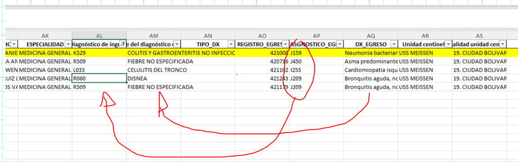

```python
df_sin_duplicados_columnas.columns
```

```
Index(['CODIGO_USS', 'NOMBRE_USS', 'TIPO_HC', 'NOMBRE_TIPOHC', 'INGRESO',
       'FECHA_INGRESO', 'TIPO_INGRESO', 'INGRESO_POR', 'FECHA_ATENCION',
       'AREA', 'NOMBRE_AREA', 'TIPO_AREA_SERVICIO', 'AREA_URGENCIAS', 'FOLIO',
       'TIPO_ID', 'DOCUMENTO', 'PRIMER_NOMBRE', 'SEGUNDO_NOMBRE',
       'PRIMER_APELLIDO', 'SEGUNDO_APELLIDO', 'FECHA_NACIMIENTO', 'EDAD',
       'GENERO', 'CODIGO_BARRIO', 'NOMBRE_BARRIO', 'DIRECCION', 'TELEFONO',
       'LOCALIDAD', 'NOMBRE_LOCALIDAD', 'TIPO_PACIENTE', 'TIPO_AFILIADO',
       'TERCERO_ENTIDAD', 'NOMBRE_TERCERO', 'PLAN_BENEFICIOS', 'ID_MEDICO',
       'NOMBRE_MEDICO', 'ESPECIALIDAD', 'DIAGNOSTICO', 'NOMBRE_DIAGNOSTICO',
       'TIPO_DX', 'REGISTRO_EGRESO', 'DIASGNOSTICO_EGRESO', 'DX_EGRESO'],
      dtype='object')
```

```python
import pandas as pd

def reemplazar_ingreso_por_egreso(row):
    ingreso = str(row['DIAGNOSTICO']).strip().upper()
    egreso = str(row['DIASGNOSTICO_EGRESO']).strip().upper()

    # Si son iguales, no hacer nada
    if ingreso == egreso:
        return row

     # Si ingreso empieza por I o J y egreso por otra letra → no se hace nada
    if ingreso.startswith(('I', 'J')) and not egreso.startswith(('I', 'J')):
        return row


    # Si ingreso no empieza por I o J y egreso sí → se reemplaza ingreso
    if not ingreso.startswith(('I', 'J')) and egreso.startswith(('I', 'J')):
        row['DIAGNOSTICO'] = egreso
        row['NOMBRE_DIAGNOSTICO'] = row['DX_EGRESO']

    # En los demás casos, no se hace nada
    return row
```

```python
# Aplicar la función fila por fila
df_sin_duplicados_columnas = df_sin_duplicados_columnas.apply(reemplazar_ingreso_por_egreso, axis=1)
```

```python
excluir_codigos=["I770", "I952", "I970", "I971", "I972", "I978", "I979", "J341", "J342", "J380", "J386", "J690", "J691", "J698", "J700", "J701", "J702", "J703", "J704", "J708", "J709", "J940", "J941", "J942", "J950", "J951", "J952", "J953", "J954", "J955", "J958", "J959", "J986" ]
```

Este código elimina del DataFrame las filas donde el diagnóstico o el diagnóstico de egreso estén dentro de una lista de códigos a excluir.

### Construir aquí la funcion

```python
df_sin_duplicados_columnas = df_sin_duplicados_columnas[
    ~df_sin_duplicados_columnas["DIAGNOSTICO"].isin(excluir_codigos) &
    ~df_sin_duplicados_columnas["DIASGNOSTICO_EGRESO"].isin(excluir_codigos)
]
```

```python
df_sin_duplicados_columnas.to_excel("Base_Meissen_primera_base.xlsx",index=False)
```

# parte 2

1. Unidad centinela: En la base se registra la unidad centinela correspondiente:
- CAPS CHAPINERO
- HOSPITAL UNIVERSITARIO CLINICA SAN RAFAEL
- USS MEISSEN
- USS KENNEDY

```python
df_sin_duplicados_columnas["Unidad centinela"]="USS MEISSEN"
```

```python
df_sin_duplicados_columnas
```

|  | CODIGO_USS | NOMBRE_USS | TIPO_HC | NOMBRE_TIPOHC | INGRESO | FECHA_INGRESO | TIPO_INGRESO | INGRESO_POR | FECHA_ATENCION | AREA | ... | ID_MEDICO | NOMBRE_MEDICO | ESPECIALIDAD | DIAGNOSTICO | NOMBRE_DIAGNOSTICO | TIPO_DX | REGISTRO_EGRESO | DIASGNOSTICO_EGRESO | DX_EGRESO | Unidad centinela |
| --- | --- | --- | --- | --- | --- | --- | --- | --- | --- | --- | --- | --- | --- | --- | --- | --- | --- | --- | --- | --- | --- |
| 0 | ME | HOSPITAL MEISSEN | HCW068 | CONSULTA INICIAL DE URGENCIAS | 16136467 | 2025-04-13 01:10:36.813 | AMBULATORIO | URGENCIAS | 2025-04-13 | B01ME | ... | 1010067295 | AVELLANEDA PINZON XIMENA | MEDICINA GENERAL MIXTA | J989 | TRASTORNO RESPIRATORIO, NO ESPECIFICADO ... | PRINCIPAL | NaN |  | NaN | USS MEISSEN |
| 1 | ME | HOSPITAL MEISSEN | HCW089 | CONSULTA INICIAL DE URGENCIAS PEDIATRICA | 16136476 | 2025-04-13 01:55:18.460 | AMBULATORIO | URGENCIAS | 2025-04-13 | B01ME | ... | 1000159382 | ROMERO TRIANA ANDERSON CAMILO | MEDICINA GENERAL MIXTA | J050 | LARINGITIS OBSTRUCTIVA, AGUDA [CRUP] ... | PRINCIPAL | NaN |  | NaN | USS MEISSEN |
| 2 | ME | HOSPITAL MEISSEN | HCW089 | CONSULTA INICIAL DE URGENCIAS PEDIATRICA | 16136483 | 2025-04-13 03:08:20.957 | AMBULATORIO | URGENCIAS | 2025-04-13 | B01ME | ... | 1007161544 | RUIZ HERNANDEZ JEISON ALEJANDRO | MEDICINA GENERAL MIXTA | J219 | BRONQUIOLITIS AGUDA, NO ESPECIFICADA ... | PRINCIPAL | NaN |  | NaN | USS MEISSEN |
| 3 | ME | HOSPITAL MEISSEN | HCW068 | CONSULTA INICIAL DE URGENCIAS | 16136504 | 2025-04-13 06:26:59.807 | AMBULATORIO | URGENCIAS | 2025-04-13 | B01ME | ... | 1091811125 | GUERRERO ARAQUE LEANDRO JAVIER | MEDICINA GENERAL | J441 | ENFERMEDAD PULMONAR OBSTRUCTIVA CRONICA CON EX... | PRINCIPAL | NaN |  | NaN | USS MEISSEN |
| 4 | ME | HOSPITAL MEISSEN | HCW089 | CONSULTA INICIAL DE URGENCIAS PEDIATRICA | 16136545 | 2025-04-13 08:01:10.533 | AMBULATORIO | URGENCIAS | 2025-04-13 | B01ME | ... | 52384021 | AREVALO VILLAMARIN INGRID TATIANA | MEDICINA GENERAL | J459 | ASMA, NO ESPECIFICADA ... | PRINCIPAL | NaN |  | NaN | USS MEISSEN |
| ... | ... | ... | ... | ... | ... | ... | ... | ... | ... | ... | ... | ... | ... | ... | ... | ... | ... | ... | ... | ... | ... |
| 218 | ME | HOSPITAL MEISSEN | HCW089 | CONSULTA INICIAL DE URGENCIAS PEDIATRICA | 16152595 | 2025-04-19 21:10:16.987 | AMBULATORIO | URGENCIAS | 2025-04-19 | B01ME | ... | 1033798506 | ZAPATA RODRIGUEZ JUAN SEBASTIAN | MEDICINA GENERAL - PROGRAMAS | J00X | RINOFARINGITIS AGUDA (RESFRIADO COMUN) ... | PRINCIPAL | NaN |  | NaN | USS MEISSEN |
| 219 | ME | HOSPITAL MEISSEN | HCW089 | CONSULTA INICIAL DE URGENCIAS PEDIATRICA | 16152727 | 2025-04-19 22:19:19.900 | AMBULATORIO | URGENCIAS | 2025-04-19 | B01ME | ... | 1033798506 | ZAPATA RODRIGUEZ JUAN SEBASTIAN | MEDICINA GENERAL - PROGRAMAS | J00X | RINOFARINGITIS AGUDA (RESFRIADO COMUN) ... | PRINCIPAL | NaN |  | NaN | USS MEISSEN |
| 220 | ME | HOSPITAL MEISSEN | HCW068 | CONSULTA INICIAL DE URGENCIAS | 16152759 | 2025-04-19 22:41:59.183 | AMBULATORIO | URGENCIAS | 2025-04-19 | B01ME | ... | 93390482 | BAUTISTA GARCIA JOSE LEONEL | MEDICINA GENERAL | J399 | ENFERMEDAD DE LAS VIAS RESPIRATORIAS SUPERIORE... | PRINCIPAL | NaN |  | NaN | USS MEISSEN |
| 221 | ME | HOSPITAL MEISSEN | HCW068 | CONSULTA INICIAL DE URGENCIAS | 16152797 | 2025-04-19 22:51:34.403 | AMBULATORIO | URGENCIAS | 2025-04-20 | B01ME | ... | 93390482 | BAUTISTA GARCIA JOSE LEONEL | MEDICINA GENERAL | J441 | ENFERMEDAD PULMONAR OBSTRUCTIVA CRONICA CON EX... | PRINCIPAL | NaN |  | NaN | USS MEISSEN |
| 222 | ME | HOSPITAL MEISSEN | HCW089 | CONSULTA INICIAL DE URGENCIAS PEDIATRICA | 16152851 | 2025-04-19 23:28:06.063 | HOSPITALARIO | URGENCIAS | 2025-04-20 | B01ME | ... | 1033798506 | ZAPATA RODRIGUEZ JUAN SEBASTIAN | MEDICINA GENERAL - PROGRAMAS | J459 | ASMA, NO ESPECIFICADA ... | PRINCIPAL | NaN |  | NaN | USS MEISSEN |

223 rows × 44 columns

```python
df_sin_duplicados_columnas.columns
```

```
Index(['CODIGO_USS', 'NOMBRE_USS', 'TIPO_HC', 'NOMBRE_TIPOHC', 'INGRESO',
       'FECHA_INGRESO', 'TIPO_INGRESO', 'INGRESO_POR', 'FECHA_ATENCION',
       'AREA', 'NOMBRE_AREA', 'TIPO_AREA_SERVICIO', 'AREA_URGENCIAS', 'FOLIO',
       'TIPO_ID', 'DOCUMENTO', 'PRIMER_NOMBRE', 'SEGUNDO_NOMBRE',
       'PRIMER_APELLIDO', 'SEGUNDO_APELLIDO', 'FECHA_NACIMIENTO', 'EDAD',
       'GENERO', 'CODIGO_BARRIO', 'NOMBRE_BARRIO', 'DIRECCION', 'TELEFONO',
       'LOCALIDAD', 'NOMBRE_LOCALIDAD', 'TIPO_PACIENTE', 'TIPO_AFILIADO',
       'TERCERO_ENTIDAD', 'NOMBRE_TERCERO', 'PLAN_BENEFICIOS', 'ID_MEDICO',
       'NOMBRE_MEDICO', 'ESPECIALIDAD', 'DIAGNOSTICO', 'NOMBRE_DIAGNOSTICO',
       'TIPO_DX', 'REGISTRO_EGRESO', 'DIASGNOSTICO_EGRESO', 'DX_EGRESO',
       'Unidad centinela'],
      dtype='object')
```

```python
df_sin_duplicados_columnas['LOCALIDAD'].unique()
```

```
array([ 6, 19,  5, 10, 18,  8, 15, 99,  1,  7,  3,  9,  4, 17, 20, 16, 11,
       14])
```

### Localidad unidad centinela: Se diligencia la localidad en número y letra:

```python
# Crear el diccionario con el formato requerido
mapeo_localidades = {
    "CAPS CHAPINERO" : "12. BARRIOS UNIDOS",
    "HOSPITAL UNIVERSITARIO CLINICA SANA RAFAEL": "4. SAN CRISTOBAL",
    "USS MEISSEN" : "19. CIUDAD BOLIVAR",
    "USS KENNEDY" : "8. KENNEDY"
}
```

```python
df_sin_duplicados_columnas["Localidad unidad centinela"] = df_sin_duplicados_columnas["Unidad centinela"].map(mapeo_localidades)
```

```python
df_sin_duplicados_columnas
```

|  | CODIGO_USS | NOMBRE_USS | TIPO_HC | NOMBRE_TIPOHC | INGRESO | FECHA_INGRESO | TIPO_INGRESO | INGRESO_POR | FECHA_ATENCION | AREA | ... | NOMBRE_MEDICO | ESPECIALIDAD | DIAGNOSTICO | NOMBRE_DIAGNOSTICO | TIPO_DX | REGISTRO_EGRESO | DIASGNOSTICO_EGRESO | DX_EGRESO | Unidad centinela | Localidad unidad centinela |
| --- | --- | --- | --- | --- | --- | --- | --- | --- | --- | --- | --- | --- | --- | --- | --- | --- | --- | --- | --- | --- | --- |
| 0 | ME | HOSPITAL MEISSEN | HCW068 | CONSULTA INICIAL DE URGENCIAS | 16136467 | 2025-04-13 01:10:36.813 | AMBULATORIO | URGENCIAS | 2025-04-13 | B01ME | ... | AVELLANEDA PINZON XIMENA | MEDICINA GENERAL MIXTA | J989 | TRASTORNO RESPIRATORIO, NO ESPECIFICADO ... | PRINCIPAL | NaN |  | NaN | USS MEISSEN | 19. CIUDAD BOLIVAR |
| 1 | ME | HOSPITAL MEISSEN | HCW089 | CONSULTA INICIAL DE URGENCIAS PEDIATRICA | 16136476 | 2025-04-13 01:55:18.460 | AMBULATORIO | URGENCIAS | 2025-04-13 | B01ME | ... | ROMERO TRIANA ANDERSON CAMILO | MEDICINA GENERAL MIXTA | J050 | LARINGITIS OBSTRUCTIVA, AGUDA [CRUP] ... | PRINCIPAL | NaN |  | NaN | USS MEISSEN | 19. CIUDAD BOLIVAR |
| 2 | ME | HOSPITAL MEISSEN | HCW089 | CONSULTA INICIAL DE URGENCIAS PEDIATRICA | 16136483 | 2025-04-13 03:08:20.957 | AMBULATORIO | URGENCIAS | 2025-04-13 | B01ME | ... | RUIZ HERNANDEZ JEISON ALEJANDRO | MEDICINA GENERAL MIXTA | J219 | BRONQUIOLITIS AGUDA, NO ESPECIFICADA ... | PRINCIPAL | NaN |  | NaN | USS MEISSEN | 19. CIUDAD BOLIVAR |
| 3 | ME | HOSPITAL MEISSEN | HCW068 | CONSULTA INICIAL DE URGENCIAS | 16136504 | 2025-04-13 06:26:59.807 | AMBULATORIO | URGENCIAS | 2025-04-13 | B01ME | ... | GUERRERO ARAQUE LEANDRO JAVIER | MEDICINA GENERAL | J441 | ENFERMEDAD PULMONAR OBSTRUCTIVA CRONICA CON EX... | PRINCIPAL | NaN |  | NaN | USS MEISSEN | 19. CIUDAD BOLIVAR |
| 4 | ME | HOSPITAL MEISSEN | HCW089 | CONSULTA INICIAL DE URGENCIAS PEDIATRICA | 16136545 | 2025-04-13 08:01:10.533 | AMBULATORIO | URGENCIAS | 2025-04-13 | B01ME | ... | AREVALO VILLAMARIN INGRID TATIANA | MEDICINA GENERAL | J459 | ASMA, NO ESPECIFICADA ... | PRINCIPAL | NaN |  | NaN | USS MEISSEN | 19. CIUDAD BOLIVAR |
| ... | ... | ... | ... | ... | ... | ... | ... | ... | ... | ... | ... | ... | ... | ... | ... | ... | ... | ... | ... | ... | ... |
| 218 | ME | HOSPITAL MEISSEN | HCW089 | CONSULTA INICIAL DE URGENCIAS PEDIATRICA | 16152595 | 2025-04-19 21:10:16.987 | AMBULATORIO | URGENCIAS | 2025-04-19 | B01ME | ... | ZAPATA RODRIGUEZ JUAN SEBASTIAN | MEDICINA GENERAL - PROGRAMAS | J00X | RINOFARINGITIS AGUDA (RESFRIADO COMUN) ... | PRINCIPAL | NaN |  | NaN | USS MEISSEN | 19. CIUDAD BOLIVAR |
| 219 | ME | HOSPITAL MEISSEN | HCW089 | CONSULTA INICIAL DE URGENCIAS PEDIATRICA | 16152727 | 2025-04-19 22:19:19.900 | AMBULATORIO | URGENCIAS | 2025-04-19 | B01ME | ... | ZAPATA RODRIGUEZ JUAN SEBASTIAN | MEDICINA GENERAL - PROGRAMAS | J00X | RINOFARINGITIS AGUDA (RESFRIADO COMUN) ... | PRINCIPAL | NaN |  | NaN | USS MEISSEN | 19. CIUDAD BOLIVAR |
| 220 | ME | HOSPITAL MEISSEN | HCW068 | CONSULTA INICIAL DE URGENCIAS | 16152759 | 2025-04-19 22:41:59.183 | AMBULATORIO | URGENCIAS | 2025-04-19 | B01ME | ... | BAUTISTA GARCIA JOSE LEONEL | MEDICINA GENERAL | J399 | ENFERMEDAD DE LAS VIAS RESPIRATORIAS SUPERIORE... | PRINCIPAL | NaN |  | NaN | USS MEISSEN | 19. CIUDAD BOLIVAR |
| 221 | ME | HOSPITAL MEISSEN | HCW068 | CONSULTA INICIAL DE URGENCIAS | 16152797 | 2025-04-19 22:51:34.403 | AMBULATORIO | URGENCIAS | 2025-04-20 | B01ME | ... | BAUTISTA GARCIA JOSE LEONEL | MEDICINA GENERAL | J441 | ENFERMEDAD PULMONAR OBSTRUCTIVA CRONICA CON EX... | PRINCIPAL | NaN |  | NaN | USS MEISSEN | 19. CIUDAD BOLIVAR |
| 222 | ME | HOSPITAL MEISSEN | HCW089 | CONSULTA INICIAL DE URGENCIAS PEDIATRICA | 16152851 | 2025-04-19 23:28:06.063 | HOSPITALARIO | URGENCIAS | 2025-04-20 | B01ME | ... | ZAPATA RODRIGUEZ JUAN SEBASTIAN | MEDICINA GENERAL - PROGRAMAS | J459 | ASMA, NO ESPECIFICADA ... | PRINCIPAL | NaN |  | NaN | USS MEISSEN | 19. CIUDAD BOLIVAR |

223 rows × 45 columns

### MES: En número

```python
# Convertir a tipo datetime
df_sin_duplicados_columnas['FECHA_INGRESO'] = pd.to_datetime(df_sin_duplicados_columnas['FECHA_INGRESO'])

# Extraer el número del mes
df_sin_duplicados_columnas['MES'] = df_sin_duplicados_columnas['FECHA_INGRESO'].dt.month
```

```python
df_sin_duplicados_columnas
```

|  | CODIGO_USS | NOMBRE_USS | TIPO_HC | NOMBRE_TIPOHC | INGRESO | FECHA_INGRESO | TIPO_INGRESO | INGRESO_POR | FECHA_ATENCION | AREA | ... | ESPECIALIDAD | DIAGNOSTICO | NOMBRE_DIAGNOSTICO | TIPO_DX | REGISTRO_EGRESO | DIASGNOSTICO_EGRESO | DX_EGRESO | Unidad centinela | Localidad unidad centinela | MES |
| --- | --- | --- | --- | --- | --- | --- | --- | --- | --- | --- | --- | --- | --- | --- | --- | --- | --- | --- | --- | --- | --- |
| 0 | ME | HOSPITAL MEISSEN | HCW068 | CONSULTA INICIAL DE URGENCIAS | 16136467 | 2025-04-13 01:10:36.813 | AMBULATORIO | URGENCIAS | 2025-04-13 | B01ME | ... | MEDICINA GENERAL MIXTA | J989 | TRASTORNO RESPIRATORIO, NO ESPECIFICADO ... | PRINCIPAL | NaN |  | NaN | USS MEISSEN | 19. CIUDAD BOLIVAR | 4 |
| 1 | ME | HOSPITAL MEISSEN | HCW089 | CONSULTA INICIAL DE URGENCIAS PEDIATRICA | 16136476 | 2025-04-13 01:55:18.460 | AMBULATORIO | URGENCIAS | 2025-04-13 | B01ME | ... | MEDICINA GENERAL MIXTA | J050 | LARINGITIS OBSTRUCTIVA, AGUDA [CRUP] ... | PRINCIPAL | NaN |  | NaN | USS MEISSEN | 19. CIUDAD BOLIVAR | 4 |
| 2 | ME | HOSPITAL MEISSEN | HCW089 | CONSULTA INICIAL DE URGENCIAS PEDIATRICA | 16136483 | 2025-04-13 03:08:20.957 | AMBULATORIO | URGENCIAS | 2025-04-13 | B01ME | ... | MEDICINA GENERAL MIXTA | J219 | BRONQUIOLITIS AGUDA, NO ESPECIFICADA ... | PRINCIPAL | NaN |  | NaN | USS MEISSEN | 19. CIUDAD BOLIVAR | 4 |
| 3 | ME | HOSPITAL MEISSEN | HCW068 | CONSULTA INICIAL DE URGENCIAS | 16136504 | 2025-04-13 06:26:59.807 | AMBULATORIO | URGENCIAS | 2025-04-13 | B01ME | ... | MEDICINA GENERAL | J441 | ENFERMEDAD PULMONAR OBSTRUCTIVA CRONICA CON EX... | PRINCIPAL | NaN |  | NaN | USS MEISSEN | 19. CIUDAD BOLIVAR | 4 |
| 4 | ME | HOSPITAL MEISSEN | HCW089 | CONSULTA INICIAL DE URGENCIAS PEDIATRICA | 16136545 | 2025-04-13 08:01:10.533 | AMBULATORIO | URGENCIAS | 2025-04-13 | B01ME | ... | MEDICINA GENERAL | J459 | ASMA, NO ESPECIFICADA ... | PRINCIPAL | NaN |  | NaN | USS MEISSEN | 19. CIUDAD BOLIVAR | 4 |
| ... | ... | ... | ... | ... | ... | ... | ... | ... | ... | ... | ... | ... | ... | ... | ... | ... | ... | ... | ... | ... | ... |
| 218 | ME | HOSPITAL MEISSEN | HCW089 | CONSULTA INICIAL DE URGENCIAS PEDIATRICA | 16152595 | 2025-04-19 21:10:16.987 | AMBULATORIO | URGENCIAS | 2025-04-19 | B01ME | ... | MEDICINA GENERAL - PROGRAMAS | J00X | RINOFARINGITIS AGUDA (RESFRIADO COMUN) ... | PRINCIPAL | NaN |  | NaN | USS MEISSEN | 19. CIUDAD BOLIVAR | 4 |
| 219 | ME | HOSPITAL MEISSEN | HCW089 | CONSULTA INICIAL DE URGENCIAS PEDIATRICA | 16152727 | 2025-04-19 22:19:19.900 | AMBULATORIO | URGENCIAS | 2025-04-19 | B01ME | ... | MEDICINA GENERAL - PROGRAMAS | J00X | RINOFARINGITIS AGUDA (RESFRIADO COMUN) ... | PRINCIPAL | NaN |  | NaN | USS MEISSEN | 19. CIUDAD BOLIVAR | 4 |
| 220 | ME | HOSPITAL MEISSEN | HCW068 | CONSULTA INICIAL DE URGENCIAS | 16152759 | 2025-04-19 22:41:59.183 | AMBULATORIO | URGENCIAS | 2025-04-19 | B01ME | ... | MEDICINA GENERAL | J399 | ENFERMEDAD DE LAS VIAS RESPIRATORIAS SUPERIORE... | PRINCIPAL | NaN |  | NaN | USS MEISSEN | 19. CIUDAD BOLIVAR | 4 |
| 221 | ME | HOSPITAL MEISSEN | HCW068 | CONSULTA INICIAL DE URGENCIAS | 16152797 | 2025-04-19 22:51:34.403 | AMBULATORIO | URGENCIAS | 2025-04-20 | B01ME | ... | MEDICINA GENERAL | J441 | ENFERMEDAD PULMONAR OBSTRUCTIVA CRONICA CON EX... | PRINCIPAL | NaN |  | NaN | USS MEISSEN | 19. CIUDAD BOLIVAR | 4 |
| 222 | ME | HOSPITAL MEISSEN | HCW089 | CONSULTA INICIAL DE URGENCIAS PEDIATRICA | 16152851 | 2025-04-19 23:28:06.063 | HOSPITALARIO | URGENCIAS | 2025-04-20 | B01ME | ... | MEDICINA GENERAL - PROGRAMAS | J459 | ASMA, NO ESPECIFICADA ... | PRINCIPAL | NaN |  | NaN | USS MEISSEN | 19. CIUDAD BOLIVAR | 4 |

223 rows × 46 columns

### Fecha consulta: Que quede registro de formato fecha dd/mm/aaaa

```python
df_sin_duplicados_columnas['Fecha consulta'] = df_sin_duplicados_columnas['FECHA_INGRESO'].dt.strftime('%d/%m/%Y')
```

```python
df_sin_duplicados_columnas
```

|  | CODIGO_USS | NOMBRE_USS | TIPO_HC | NOMBRE_TIPOHC | INGRESO | FECHA_INGRESO | TIPO_INGRESO | INGRESO_POR | FECHA_ATENCION | AREA | ... | DIAGNOSTICO | NOMBRE_DIAGNOSTICO | TIPO_DX | REGISTRO_EGRESO | DIASGNOSTICO_EGRESO | DX_EGRESO | Unidad centinela | Localidad unidad centinela | MES | Fecha consulta |
| --- | --- | --- | --- | --- | --- | --- | --- | --- | --- | --- | --- | --- | --- | --- | --- | --- | --- | --- | --- | --- | --- |
| 0 | ME | HOSPITAL MEISSEN | HCW068 | CONSULTA INICIAL DE URGENCIAS | 16136467 | 2025-04-13 01:10:36.813 | AMBULATORIO | URGENCIAS | 2025-04-13 | B01ME | ... | J989 | TRASTORNO RESPIRATORIO, NO ESPECIFICADO ... | PRINCIPAL | NaN |  | NaN | USS MEISSEN | 19. CIUDAD BOLIVAR | 4 | 13/04/2025 |
| 1 | ME | HOSPITAL MEISSEN | HCW089 | CONSULTA INICIAL DE URGENCIAS PEDIATRICA | 16136476 | 2025-04-13 01:55:18.460 | AMBULATORIO | URGENCIAS | 2025-04-13 | B01ME | ... | J050 | LARINGITIS OBSTRUCTIVA, AGUDA [CRUP] ... | PRINCIPAL | NaN |  | NaN | USS MEISSEN | 19. CIUDAD BOLIVAR | 4 | 13/04/2025 |
| 2 | ME | HOSPITAL MEISSEN | HCW089 | CONSULTA INICIAL DE URGENCIAS PEDIATRICA | 16136483 | 2025-04-13 03:08:20.957 | AMBULATORIO | URGENCIAS | 2025-04-13 | B01ME | ... | J219 | BRONQUIOLITIS AGUDA, NO ESPECIFICADA ... | PRINCIPAL | NaN |  | NaN | USS MEISSEN | 19. CIUDAD BOLIVAR | 4 | 13/04/2025 |
| 3 | ME | HOSPITAL MEISSEN | HCW068 | CONSULTA INICIAL DE URGENCIAS | 16136504 | 2025-04-13 06:26:59.807 | AMBULATORIO | URGENCIAS | 2025-04-13 | B01ME | ... | J441 | ENFERMEDAD PULMONAR OBSTRUCTIVA CRONICA CON EX... | PRINCIPAL | NaN |  | NaN | USS MEISSEN | 19. CIUDAD BOLIVAR | 4 | 13/04/2025 |
| 4 | ME | HOSPITAL MEISSEN | HCW089 | CONSULTA INICIAL DE URGENCIAS PEDIATRICA | 16136545 | 2025-04-13 08:01:10.533 | AMBULATORIO | URGENCIAS | 2025-04-13 | B01ME | ... | J459 | ASMA, NO ESPECIFICADA ... | PRINCIPAL | NaN |  | NaN | USS MEISSEN | 19. CIUDAD BOLIVAR | 4 | 13/04/2025 |
| ... | ... | ... | ... | ... | ... | ... | ... | ... | ... | ... | ... | ... | ... | ... | ... | ... | ... | ... | ... | ... | ... |
| 218 | ME | HOSPITAL MEISSEN | HCW089 | CONSULTA INICIAL DE URGENCIAS PEDIATRICA | 16152595 | 2025-04-19 21:10:16.987 | AMBULATORIO | URGENCIAS | 2025-04-19 | B01ME | ... | J00X | RINOFARINGITIS AGUDA (RESFRIADO COMUN) ... | PRINCIPAL | NaN |  | NaN | USS MEISSEN | 19. CIUDAD BOLIVAR | 4 | 19/04/2025 |
| 219 | ME | HOSPITAL MEISSEN | HCW089 | CONSULTA INICIAL DE URGENCIAS PEDIATRICA | 16152727 | 2025-04-19 22:19:19.900 | AMBULATORIO | URGENCIAS | 2025-04-19 | B01ME | ... | J00X | RINOFARINGITIS AGUDA (RESFRIADO COMUN) ... | PRINCIPAL | NaN |  | NaN | USS MEISSEN | 19. CIUDAD BOLIVAR | 4 | 19/04/2025 |
| 220 | ME | HOSPITAL MEISSEN | HCW068 | CONSULTA INICIAL DE URGENCIAS | 16152759 | 2025-04-19 22:41:59.183 | AMBULATORIO | URGENCIAS | 2025-04-19 | B01ME | ... | J399 | ENFERMEDAD DE LAS VIAS RESPIRATORIAS SUPERIORE... | PRINCIPAL | NaN |  | NaN | USS MEISSEN | 19. CIUDAD BOLIVAR | 4 | 19/04/2025 |
| 221 | ME | HOSPITAL MEISSEN | HCW068 | CONSULTA INICIAL DE URGENCIAS | 16152797 | 2025-04-19 22:51:34.403 | AMBULATORIO | URGENCIAS | 2025-04-20 | B01ME | ... | J441 | ENFERMEDAD PULMONAR OBSTRUCTIVA CRONICA CON EX... | PRINCIPAL | NaN |  | NaN | USS MEISSEN | 19. CIUDAD BOLIVAR | 4 | 19/04/2025 |
| 222 | ME | HOSPITAL MEISSEN | HCW089 | CONSULTA INICIAL DE URGENCIAS PEDIATRICA | 16152851 | 2025-04-19 23:28:06.063 | HOSPITALARIO | URGENCIAS | 2025-04-20 | B01ME | ... | J459 | ASMA, NO ESPECIFICADA ... | PRINCIPAL | NaN |  | NaN | USS MEISSEN | 19. CIUDAD BOLIVAR | 4 | 19/04/2025 |

223 rows × 47 columns

```python
df_sin_duplicados_columnas.columns
```

```
Index(['CODIGO_USS', 'NOMBRE_USS', 'TIPO_HC', 'NOMBRE_TIPOHC', 'INGRESO',
       'FECHA_INGRESO', 'TIPO_INGRESO', 'INGRESO_POR', 'FECHA_ATENCION',
       'AREA', 'NOMBRE_AREA', 'TIPO_AREA_SERVICIO', 'AREA_URGENCIAS', 'FOLIO',
       'TIPO_ID', 'DOCUMENTO', 'PRIMER_NOMBRE', 'SEGUNDO_NOMBRE',
       'PRIMER_APELLIDO', 'SEGUNDO_APELLIDO', 'FECHA_NACIMIENTO', 'EDAD',
       'GENERO', 'CODIGO_BARRIO', 'NOMBRE_BARRIO', 'DIRECCION', 'TELEFONO',
       'LOCALIDAD', 'NOMBRE_LOCALIDAD', 'TIPO_PACIENTE', 'TIPO_AFILIADO',
       'TERCERO_ENTIDAD', 'NOMBRE_TERCERO', 'PLAN_BENEFICIOS', 'ID_MEDICO',
       'NOMBRE_MEDICO', 'ESPECIALIDAD', 'DIAGNOSTICO', 'NOMBRE_DIAGNOSTICO',
       'TIPO_DX', 'REGISTRO_EGRESO', 'DIASGNOSTICO_EGRESO', 'DX_EGRESO',
       'Unidad centinela', 'Localidad unidad centinela', 'MES',
       'Fecha consulta'],
      dtype='object')
```

#### Semana epidemiológica: De acuerdo a la semana epidemiológica correspondiente, pero si ya quedó ese código en la otra base, no se si en esta base sea necesario.

```python
semanas_2025 = {
    1: ("2024-12-29", "2025-01-04"),
    2: ("2025-01-05", "2025-01-11"),
    3: ("2025-01-12", "2025-01-18"),
    4: ("2025-01-19", "2025-01-25"),
    5: ("2025-01-26", "2025-02-01"),
    6: ("2025-02-02", "2025-02-08"),
    7: ("2025-02-09", "2025-02-15"),
    8: ("2025-02-16", "2025-02-22"),
    9: ("2025-02-23", "2025-03-01"),
    10: ("2025-03-02", "2025-03-08"),
    11: ("2025-03-09", "2025-03-15"),
    12: ("2025-03-16", "2025-03-22"),
    13: ("2025-03-23", "2025-03-29"),
    14: ("2025-03-30", "2025-04-05"),
    15: ("2025-04-06", "2025-04-12"),
    16: ("2025-04-13", "2025-04-19"),
    17: ("2025-04-20", "2025-04-26"),
    18: ("2025-04-27", "2025-05-03"),
    19: ("2025-05-04", "2025-05-10"),
    20: ("2025-05-11", "2025-05-17"),
    21: ("2025-05-18", "2025-05-24"),
    22: ("2025-05-25", "2025-05-31"),
    23: ("2025-06-01", "2025-06-07"),
    24: ("2025-06-08", "2025-06-14"),
    25: ("2025-06-15", "2025-06-21"),
    26: ("2025-06-22", "2025-06-28"),
    27: ("2025-06-29", "2025-07-05"),
    28: ("2025-07-06", "2025-07-12"),
    29: ("2025-07-13", "2025-07-19"),
    30: ("2025-07-20", "2025-07-26"),
    31: ("2025-07-27", "2025-08-02"),
    32: ("2025-08-03", "2025-08-09"),
    33: ("2025-08-10", "2025-08-16"),
    34: ("2025-08-17", "2025-08-23"),
    35: ("2025-08-24", "2025-08-30"),
    36: ("2025-08-31", "2025-09-06"),
    37: ("2025-09-07", "2025-09-13"),
    38: ("2025-09-14", "2025-09-20"),
    39: ("2025-09-21", "2025-09-27"),
    40: ("2025-09-28", "2025-10-04"),
    41: ("2025-10-05", "2025-10-11"),
    42: ("2025-10-12", "2025-10-18"),
    43: ("2025-10-19", "2025-10-25"),
    44: ("2025-10-26", "2025-11-01"),
    45: ("2025-11-02", "2025-11-08"),
    46: ("2025-11-09", "2025-11-15"),
    47: ("2025-11-16", "2025-11-22"),
    48: ("2025-11-23", "2025-11-29"),
    49: ("2025-11-30", "2025-12-06"),
    50: ("2025-12-07", "2025-12-13"),
    51: ("2025-12-14", "2025-12-20"),
    52: ("2025-12-21", "2025-12-27"),
    53: ("2025-12-28", "2026-01-03"),
}
```

```python
df_sin_duplicados_columnas["Fecha consulta"] = pd.to_datetime(
    df_sin_duplicados_columnas["Fecha consulta"],
    format="%d/%m/%Y"   # Ajusta según tu necesidad real
)

#
```

```python
import pandas as pd

semanas_ordenadas = sorted(semanas_2025.keys())
bins = []

for i in semanas_ordenadas:
    # Inicio exacto tal como está en el diccionario
    inicio = pd.to_datetime(semanas_2025[i][0])
    # Para que 'fin' quede incluido, le sumamos 1 día y usamos el bin abierto
    # a la derecha => [inicio, fin+1)
    bins.append(inicio)

# El "cierre" del último bin será la fecha final de la última semana + 1 día
fin_ultima_sem = pd.to_datetime(semanas_2025[semanas_ordenadas[-1]][1])
bins.append(fin_ultima_sem + pd.Timedelta(days=1))

# Etiquetas
labels = [f"{i}" for i in semanas_ordenadas]

df_sin_duplicados_columnas["Semana epidemiologica"] = pd.cut(
    df_sin_duplicados_columnas["Fecha consulta"],
    bins=bins,
    labels=labels,
    right=False  # ¡Cerramos por la izquierda [inicio, fin)!
)
```

```python
df_sin_duplicados_columnas
```

|  | CODIGO_USS | NOMBRE_USS | TIPO_HC | NOMBRE_TIPOHC | INGRESO | FECHA_INGRESO | TIPO_INGRESO | INGRESO_POR | FECHA_ATENCION | AREA | ... | NOMBRE_DIAGNOSTICO | TIPO_DX | REGISTRO_EGRESO | DIASGNOSTICO_EGRESO | DX_EGRESO | Unidad centinela | Localidad unidad centinela | MES | Fecha consulta | Semana epidemiologica |
| --- | --- | --- | --- | --- | --- | --- | --- | --- | --- | --- | --- | --- | --- | --- | --- | --- | --- | --- | --- | --- | --- |
| 0 | ME | HOSPITAL MEISSEN | HCW068 | CONSULTA INICIAL DE URGENCIAS | 16136467 | 2025-04-13 01:10:36.813 | AMBULATORIO | URGENCIAS | 2025-04-13 | B01ME | ... | TRASTORNO RESPIRATORIO, NO ESPECIFICADO ... | PRINCIPAL | NaN |  | NaN | USS MEISSEN | 19. CIUDAD BOLIVAR | 4 | 2025-04-13 | 16 |
| 1 | ME | HOSPITAL MEISSEN | HCW089 | CONSULTA INICIAL DE URGENCIAS PEDIATRICA | 16136476 | 2025-04-13 01:55:18.460 | AMBULATORIO | URGENCIAS | 2025-04-13 | B01ME | ... | LARINGITIS OBSTRUCTIVA, AGUDA [CRUP] ... | PRINCIPAL | NaN |  | NaN | USS MEISSEN | 19. CIUDAD BOLIVAR | 4 | 2025-04-13 | 16 |
| 2 | ME | HOSPITAL MEISSEN | HCW089 | CONSULTA INICIAL DE URGENCIAS PEDIATRICA | 16136483 | 2025-04-13 03:08:20.957 | AMBULATORIO | URGENCIAS | 2025-04-13 | B01ME | ... | BRONQUIOLITIS AGUDA, NO ESPECIFICADA ... | PRINCIPAL | NaN |  | NaN | USS MEISSEN | 19. CIUDAD BOLIVAR | 4 | 2025-04-13 | 16 |
| 3 | ME | HOSPITAL MEISSEN | HCW068 | CONSULTA INICIAL DE URGENCIAS | 16136504 | 2025-04-13 06:26:59.807 | AMBULATORIO | URGENCIAS | 2025-04-13 | B01ME | ... | ENFERMEDAD PULMONAR OBSTRUCTIVA CRONICA CON EX... | PRINCIPAL | NaN |  | NaN | USS MEISSEN | 19. CIUDAD BOLIVAR | 4 | 2025-04-13 | 16 |
| 4 | ME | HOSPITAL MEISSEN | HCW089 | CONSULTA INICIAL DE URGENCIAS PEDIATRICA | 16136545 | 2025-04-13 08:01:10.533 | AMBULATORIO | URGENCIAS | 2025-04-13 | B01ME | ... | ASMA, NO ESPECIFICADA ... | PRINCIPAL | NaN |  | NaN | USS MEISSEN | 19. CIUDAD BOLIVAR | 4 | 2025-04-13 | 16 |
| ... | ... | ... | ... | ... | ... | ... | ... | ... | ... | ... | ... | ... | ... | ... | ... | ... | ... | ... | ... | ... | ... |
| 218 | ME | HOSPITAL MEISSEN | HCW089 | CONSULTA INICIAL DE URGENCIAS PEDIATRICA | 16152595 | 2025-04-19 21:10:16.987 | AMBULATORIO | URGENCIAS | 2025-04-19 | B01ME | ... | RINOFARINGITIS AGUDA (RESFRIADO COMUN) ... | PRINCIPAL | NaN |  | NaN | USS MEISSEN | 19. CIUDAD BOLIVAR | 4 | 2025-04-19 | 16 |
| 219 | ME | HOSPITAL MEISSEN | HCW089 | CONSULTA INICIAL DE URGENCIAS PEDIATRICA | 16152727 | 2025-04-19 22:19:19.900 | AMBULATORIO | URGENCIAS | 2025-04-19 | B01ME | ... | RINOFARINGITIS AGUDA (RESFRIADO COMUN) ... | PRINCIPAL | NaN |  | NaN | USS MEISSEN | 19. CIUDAD BOLIVAR | 4 | 2025-04-19 | 16 |
| 220 | ME | HOSPITAL MEISSEN | HCW068 | CONSULTA INICIAL DE URGENCIAS | 16152759 | 2025-04-19 22:41:59.183 | AMBULATORIO | URGENCIAS | 2025-04-19 | B01ME | ... | ENFERMEDAD DE LAS VIAS RESPIRATORIAS SUPERIORE... | PRINCIPAL | NaN |  | NaN | USS MEISSEN | 19. CIUDAD BOLIVAR | 4 | 2025-04-19 | 16 |
| 221 | ME | HOSPITAL MEISSEN | HCW068 | CONSULTA INICIAL DE URGENCIAS | 16152797 | 2025-04-19 22:51:34.403 | AMBULATORIO | URGENCIAS | 2025-04-20 | B01ME | ... | ENFERMEDAD PULMONAR OBSTRUCTIVA CRONICA CON EX... | PRINCIPAL | NaN |  | NaN | USS MEISSEN | 19. CIUDAD BOLIVAR | 4 | 2025-04-19 | 16 |
| 222 | ME | HOSPITAL MEISSEN | HCW089 | CONSULTA INICIAL DE URGENCIAS PEDIATRICA | 16152851 | 2025-04-19 23:28:06.063 | HOSPITALARIO | URGENCIAS | 2025-04-20 | B01ME | ... | ASMA, NO ESPECIFICADA ... | PRINCIPAL | NaN |  | NaN | USS MEISSEN | 19. CIUDAD BOLIVAR | 4 | 2025-04-19 | 16 |

223 rows × 48 columns

#### Fecha de nacimiento

```python
df_sin_duplicados_columnas['FECHA_NACIMIENTO']
```

|  | FECHA_NACIMIENTO |
| --- | --- |
| 0 | 1975-10-11 |
| 1 | 2021-08-21 |
| 2 | 2022-11-02 |
| 3 | 1949-07-14 |
| 4 | 2017-09-21 |
| ... | ... |
| 218 | 2011-12-16 |
| 219 | 2022-05-25 |
| 220 | 1948-11-12 |
| 221 | 1948-06-05 |
| 222 | 2020-04-09 |

223 rows × 1 columns

**dtype:** datetime64[ns]

```python
df_sin_duplicados_columnas["Fecha de nacimiento"]=pd.to_datetime(df_sin_duplicados_columnas['FECHA_NACIMIENTO'], format='%d/%m/%Y', errors='coerce').dt.strftime('%d/%m/%Y')
```

```python
  df_sin_duplicados_columnas
```

|  | CODIGO_USS | NOMBRE_USS | TIPO_HC | NOMBRE_TIPOHC | INGRESO | FECHA_INGRESO | TIPO_INGRESO | INGRESO_POR | FECHA_ATENCION | AREA | ... | TIPO_DX | REGISTRO_EGRESO | DIASGNOSTICO_EGRESO | DX_EGRESO | Unidad centinela | Localidad unidad centinela | MES | Fecha consulta | Semana epidemiologica | Fecha de nacimiento |
| --- | --- | --- | --- | --- | --- | --- | --- | --- | --- | --- | --- | --- | --- | --- | --- | --- | --- | --- | --- | --- | --- |
| 0 | ME | HOSPITAL MEISSEN | HCW068 | CONSULTA INICIAL DE URGENCIAS | 16136467 | 2025-04-13 01:10:36.813 | AMBULATORIO | URGENCIAS | 2025-04-13 | B01ME | ... | PRINCIPAL | NaN |  | NaN | USS MEISSEN | 19. CIUDAD BOLIVAR | 4 | 2025-04-13 | 16 | 11/10/1975 |
| 1 | ME | HOSPITAL MEISSEN | HCW089 | CONSULTA INICIAL DE URGENCIAS PEDIATRICA | 16136476 | 2025-04-13 01:55:18.460 | AMBULATORIO | URGENCIAS | 2025-04-13 | B01ME | ... | PRINCIPAL | NaN |  | NaN | USS MEISSEN | 19. CIUDAD BOLIVAR | 4 | 2025-04-13 | 16 | 21/08/2021 |
| 2 | ME | HOSPITAL MEISSEN | HCW089 | CONSULTA INICIAL DE URGENCIAS PEDIATRICA | 16136483 | 2025-04-13 03:08:20.957 | AMBULATORIO | URGENCIAS | 2025-04-13 | B01ME | ... | PRINCIPAL | NaN |  | NaN | USS MEISSEN | 19. CIUDAD BOLIVAR | 4 | 2025-04-13 | 16 | 02/11/2022 |
| 3 | ME | HOSPITAL MEISSEN | HCW068 | CONSULTA INICIAL DE URGENCIAS | 16136504 | 2025-04-13 06:26:59.807 | AMBULATORIO | URGENCIAS | 2025-04-13 | B01ME | ... | PRINCIPAL | NaN |  | NaN | USS MEISSEN | 19. CIUDAD BOLIVAR | 4 | 2025-04-13 | 16 | 14/07/1949 |
| 4 | ME | HOSPITAL MEISSEN | HCW089 | CONSULTA INICIAL DE URGENCIAS PEDIATRICA | 16136545 | 2025-04-13 08:01:10.533 | AMBULATORIO | URGENCIAS | 2025-04-13 | B01ME | ... | PRINCIPAL | NaN |  | NaN | USS MEISSEN | 19. CIUDAD BOLIVAR | 4 | 2025-04-13 | 16 | 21/09/2017 |
| ... | ... | ... | ... | ... | ... | ... | ... | ... | ... | ... | ... | ... | ... | ... | ... | ... | ... | ... | ... | ... | ... |
| 218 | ME | HOSPITAL MEISSEN | HCW089 | CONSULTA INICIAL DE URGENCIAS PEDIATRICA | 16152595 | 2025-04-19 21:10:16.987 | AMBULATORIO | URGENCIAS | 2025-04-19 | B01ME | ... | PRINCIPAL | NaN |  | NaN | USS MEISSEN | 19. CIUDAD BOLIVAR | 4 | 2025-04-19 | 16 | 16/12/2011 |
| 219 | ME | HOSPITAL MEISSEN | HCW089 | CONSULTA INICIAL DE URGENCIAS PEDIATRICA | 16152727 | 2025-04-19 22:19:19.900 | AMBULATORIO | URGENCIAS | 2025-04-19 | B01ME | ... | PRINCIPAL | NaN |  | NaN | USS MEISSEN | 19. CIUDAD BOLIVAR | 4 | 2025-04-19 | 16 | 25/05/2022 |
| 220 | ME | HOSPITAL MEISSEN | HCW068 | CONSULTA INICIAL DE URGENCIAS | 16152759 | 2025-04-19 22:41:59.183 | AMBULATORIO | URGENCIAS | 2025-04-19 | B01ME | ... | PRINCIPAL | NaN |  | NaN | USS MEISSEN | 19. CIUDAD BOLIVAR | 4 | 2025-04-19 | 16 | 12/11/1948 |
| 221 | ME | HOSPITAL MEISSEN | HCW068 | CONSULTA INICIAL DE URGENCIAS | 16152797 | 2025-04-19 22:51:34.403 | AMBULATORIO | URGENCIAS | 2025-04-20 | B01ME | ... | PRINCIPAL | NaN |  | NaN | USS MEISSEN | 19. CIUDAD BOLIVAR | 4 | 2025-04-19 | 16 | 05/06/1948 |
| 222 | ME | HOSPITAL MEISSEN | HCW089 | CONSULTA INICIAL DE URGENCIAS PEDIATRICA | 16152851 | 2025-04-19 23:28:06.063 | HOSPITALARIO | URGENCIAS | 2025-04-20 | B01ME | ... | PRINCIPAL | NaN |  | NaN | USS MEISSEN | 19. CIUDAD BOLIVAR | 4 | 2025-04-19 | 16 | 09/04/2020 |

223 rows × 49 columns

#### Tipo de documento: En caso de que el espacio se encuentre en blanco o con raya al piso, generar en ese espacio 999

```python
df_sin_duplicados_columnas["TIPO_ID"].unique()
```

```
array(['CC', 'RC', 'PT', 'TI', 'DE', 'CE'], dtype=object)
```

```python
# Reemplazar espacios en blanco o rayas al piso por "999"
df_sin_duplicados_columnas['Tipo de documento'] = df_sin_duplicados_columnas['TIPO_ID'].replace(["", "_"], "999")
```

```python
df_sin_duplicados_columnas
```

|  | CODIGO_USS | NOMBRE_USS | TIPO_HC | NOMBRE_TIPOHC | INGRESO | FECHA_INGRESO | TIPO_INGRESO | INGRESO_POR | FECHA_ATENCION | AREA | ... | REGISTRO_EGRESO | DIASGNOSTICO_EGRESO | DX_EGRESO | Unidad centinela | Localidad unidad centinela | MES | Fecha consulta | Semana epidemiologica | Fecha de nacimiento | Tipo de documento |
| --- | --- | --- | --- | --- | --- | --- | --- | --- | --- | --- | --- | --- | --- | --- | --- | --- | --- | --- | --- | --- | --- |
| 0 | ME | HOSPITAL MEISSEN | HCW068 | CONSULTA INICIAL DE URGENCIAS | 16136467 | 2025-04-13 01:10:36.813 | AMBULATORIO | URGENCIAS | 2025-04-13 | B01ME | ... | NaN |  | NaN | USS MEISSEN | 19. CIUDAD BOLIVAR | 4 | 2025-04-13 | 16 | 11/10/1975 | CC |
| 1 | ME | HOSPITAL MEISSEN | HCW089 | CONSULTA INICIAL DE URGENCIAS PEDIATRICA | 16136476 | 2025-04-13 01:55:18.460 | AMBULATORIO | URGENCIAS | 2025-04-13 | B01ME | ... | NaN |  | NaN | USS MEISSEN | 19. CIUDAD BOLIVAR | 4 | 2025-04-13 | 16 | 21/08/2021 | RC |
| 2 | ME | HOSPITAL MEISSEN | HCW089 | CONSULTA INICIAL DE URGENCIAS PEDIATRICA | 16136483 | 2025-04-13 03:08:20.957 | AMBULATORIO | URGENCIAS | 2025-04-13 | B01ME | ... | NaN |  | NaN | USS MEISSEN | 19. CIUDAD BOLIVAR | 4 | 2025-04-13 | 16 | 02/11/2022 | RC |
| 3 | ME | HOSPITAL MEISSEN | HCW068 | CONSULTA INICIAL DE URGENCIAS | 16136504 | 2025-04-13 06:26:59.807 | AMBULATORIO | URGENCIAS | 2025-04-13 | B01ME | ... | NaN |  | NaN | USS MEISSEN | 19. CIUDAD BOLIVAR | 4 | 2025-04-13 | 16 | 14/07/1949 | CC |
| 4 | ME | HOSPITAL MEISSEN | HCW089 | CONSULTA INICIAL DE URGENCIAS PEDIATRICA | 16136545 | 2025-04-13 08:01:10.533 | AMBULATORIO | URGENCIAS | 2025-04-13 | B01ME | ... | NaN |  | NaN | USS MEISSEN | 19. CIUDAD BOLIVAR | 4 | 2025-04-13 | 16 | 21/09/2017 | PT |
| ... | ... | ... | ... | ... | ... | ... | ... | ... | ... | ... | ... | ... | ... | ... | ... | ... | ... | ... | ... | ... | ... |
| 218 | ME | HOSPITAL MEISSEN | HCW089 | CONSULTA INICIAL DE URGENCIAS PEDIATRICA | 16152595 | 2025-04-19 21:10:16.987 | AMBULATORIO | URGENCIAS | 2025-04-19 | B01ME | ... | NaN |  | NaN | USS MEISSEN | 19. CIUDAD BOLIVAR | 4 | 2025-04-19 | 16 | 16/12/2011 | TI |
| 219 | ME | HOSPITAL MEISSEN | HCW089 | CONSULTA INICIAL DE URGENCIAS PEDIATRICA | 16152727 | 2025-04-19 22:19:19.900 | AMBULATORIO | URGENCIAS | 2025-04-19 | B01ME | ... | NaN |  | NaN | USS MEISSEN | 19. CIUDAD BOLIVAR | 4 | 2025-04-19 | 16 | 25/05/2022 | RC |
| 220 | ME | HOSPITAL MEISSEN | HCW068 | CONSULTA INICIAL DE URGENCIAS | 16152759 | 2025-04-19 22:41:59.183 | AMBULATORIO | URGENCIAS | 2025-04-19 | B01ME | ... | NaN |  | NaN | USS MEISSEN | 19. CIUDAD BOLIVAR | 4 | 2025-04-19 | 16 | 12/11/1948 | CC |
| 221 | ME | HOSPITAL MEISSEN | HCW068 | CONSULTA INICIAL DE URGENCIAS | 16152797 | 2025-04-19 22:51:34.403 | AMBULATORIO | URGENCIAS | 2025-04-20 | B01ME | ... | NaN |  | NaN | USS MEISSEN | 19. CIUDAD BOLIVAR | 4 | 2025-04-19 | 16 | 05/06/1948 | CC |
| 222 | ME | HOSPITAL MEISSEN | HCW089 | CONSULTA INICIAL DE URGENCIAS PEDIATRICA | 16152851 | 2025-04-19 23:28:06.063 | HOSPITALARIO | URGENCIAS | 2025-04-20 | B01ME | ... | NaN |  | NaN | USS MEISSEN | 19. CIUDAD BOLIVAR | 4 | 2025-04-19 | 16 | 09/04/2020 | RC |

223 rows × 50 columns

```python
df_sin_duplicados_columnas["Tipo de documento"].unique()
```

```
array(['CC', 'RC', 'PT', 'TI', 'DE', 'CE'], dtype=object)
```

```python
df_sin_duplicados_columnas.columns
```

```
Index(['CODIGO_USS', 'NOMBRE_USS', 'TIPO_HC', 'NOMBRE_TIPOHC', 'INGRESO',
       'FECHA_INGRESO', 'TIPO_INGRESO', 'INGRESO_POR', 'FECHA_ATENCION',
       'AREA', 'NOMBRE_AREA', 'TIPO_AREA_SERVICIO', 'AREA_URGENCIAS', 'FOLIO',
       'TIPO_ID', 'DOCUMENTO', 'PRIMER_NOMBRE', 'SEGUNDO_NOMBRE',
       'PRIMER_APELLIDO', 'SEGUNDO_APELLIDO', 'FECHA_NACIMIENTO', 'EDAD',
       'GENERO', 'CODIGO_BARRIO', 'NOMBRE_BARRIO', 'DIRECCION', 'TELEFONO',
       'LOCALIDAD', 'NOMBRE_LOCALIDAD', 'TIPO_PACIENTE', 'TIPO_AFILIADO',
       'TERCERO_ENTIDAD', 'NOMBRE_TERCERO', 'PLAN_BENEFICIOS', 'ID_MEDICO',
       'NOMBRE_MEDICO', 'ESPECIALIDAD', 'DIAGNOSTICO', 'NOMBRE_DIAGNOSTICO',
       'TIPO_DX', 'REGISTRO_EGRESO', 'DIASGNOSTICO_EGRESO', 'DX_EGRESO',
       'Unidad centinela', 'Localidad unidad centinela', 'MES',
       'Fecha consulta', 'Semana epidemiologica', 'Fecha de nacimiento',
       'Tipo de documento'],
      dtype='object')
```

#### Edad en meses: Calcular en caso de que la edad en años sea cero 0.

#### Edad años: Calcular de acuerdo a las variables fecha de nacimiento y fecha consulta.

```python
import pandas as pd
from dateutil.relativedelta import relativedelta

# Convertir las columnas a tipo datetime
df_sin_duplicados_columnas["Fecha de nacimiento"] = pd.to_datetime(df_sin_duplicados_columnas['Fecha de nacimiento'], format='%d/%m/%Y')
df_sin_duplicados_columnas['Fecha consulta'] = pd.to_datetime(df_sin_duplicados_columnas['Fecha consulta'], format='%d/%m/%Y')

# Función para calcular años y meses
def calcular_edad(row):
    nacimiento = row['Fecha de nacimiento']
    consulta = row['Fecha consulta']

    # Calcular la diferencia con relativedelta (maneja días/meses/años)
    delta = relativedelta(consulta, nacimiento)

    # Si hay al menos 1 año completo
    if delta.years >= 1:
        return pd.Series([delta.years, np.nan])
    else:
        # Calcular meses totales (años * 12 + meses)
        meses_totales = delta.years * 12 + delta.months
        return pd.Series([0, meses_totales])

# Aplicar la función y crear las columnas
df_sin_duplicados_columnas[['Edad años', 'Edad en meses']] = df_sin_duplicados_columnas.apply(calcular_edad, axis=1)
```

```python
df_sin_duplicados_columnas["Fecha de nacimiento"]=pd.to_datetime(df_sin_duplicados_columnas['Fecha de nacimiento']).dt.strftime('%d/%m/%Y')
df_sin_duplicados_columnas['Fecha consulta'] = pd.to_datetime(df_sin_duplicados_columnas['Fecha consulta']).dt.strftime('%d/%m/%Y')
```

```python
df_sin_duplicados_columnas
```

|  | CODIGO_USS | NOMBRE_USS | TIPO_HC | NOMBRE_TIPOHC | INGRESO | FECHA_INGRESO | TIPO_INGRESO | INGRESO_POR | FECHA_ATENCION | AREA | ... | DX_EGRESO | Unidad centinela | Localidad unidad centinela | MES | Fecha consulta | Semana epidemiologica | Fecha de nacimiento | Tipo de documento | Edad años | Edad en meses |
| --- | --- | --- | --- | --- | --- | --- | --- | --- | --- | --- | --- | --- | --- | --- | --- | --- | --- | --- | --- | --- | --- |
| 0 | ME | HOSPITAL MEISSEN | HCW068 | CONSULTA INICIAL DE URGENCIAS | 16136467 | 2025-04-13 01:10:36.813 | AMBULATORIO | URGENCIAS | 2025-04-13 | B01ME | ... | NaN | USS MEISSEN | 19. CIUDAD BOLIVAR | 4 | 13/04/2025 | 16 | 11/10/1975 | CC | 49.0 | NaN |
| 1 | ME | HOSPITAL MEISSEN | HCW089 | CONSULTA INICIAL DE URGENCIAS PEDIATRICA | 16136476 | 2025-04-13 01:55:18.460 | AMBULATORIO | URGENCIAS | 2025-04-13 | B01ME | ... | NaN | USS MEISSEN | 19. CIUDAD BOLIVAR | 4 | 13/04/2025 | 16 | 21/08/2021 | RC | 3.0 | NaN |
| 2 | ME | HOSPITAL MEISSEN | HCW089 | CONSULTA INICIAL DE URGENCIAS PEDIATRICA | 16136483 | 2025-04-13 03:08:20.957 | AMBULATORIO | URGENCIAS | 2025-04-13 | B01ME | ... | NaN | USS MEISSEN | 19. CIUDAD BOLIVAR | 4 | 13/04/2025 | 16 | 02/11/2022 | RC | 2.0 | NaN |
| 3 | ME | HOSPITAL MEISSEN | HCW068 | CONSULTA INICIAL DE URGENCIAS | 16136504 | 2025-04-13 06:26:59.807 | AMBULATORIO | URGENCIAS | 2025-04-13 | B01ME | ... | NaN | USS MEISSEN | 19. CIUDAD BOLIVAR | 4 | 13/04/2025 | 16 | 14/07/1949 | CC | 75.0 | NaN |
| 4 | ME | HOSPITAL MEISSEN | HCW089 | CONSULTA INICIAL DE URGENCIAS PEDIATRICA | 16136545 | 2025-04-13 08:01:10.533 | AMBULATORIO | URGENCIAS | 2025-04-13 | B01ME | ... | NaN | USS MEISSEN | 19. CIUDAD BOLIVAR | 4 | 13/04/2025 | 16 | 21/09/2017 | PT | 7.0 | NaN |
| ... | ... | ... | ... | ... | ... | ... | ... | ... | ... | ... | ... | ... | ... | ... | ... | ... | ... | ... | ... | ... | ... |
| 218 | ME | HOSPITAL MEISSEN | HCW089 | CONSULTA INICIAL DE URGENCIAS PEDIATRICA | 16152595 | 2025-04-19 21:10:16.987 | AMBULATORIO | URGENCIAS | 2025-04-19 | B01ME | ... | NaN | USS MEISSEN | 19. CIUDAD BOLIVAR | 4 | 19/04/2025 | 16 | 16/12/2011 | TI | 13.0 | NaN |
| 219 | ME | HOSPITAL MEISSEN | HCW089 | CONSULTA INICIAL DE URGENCIAS PEDIATRICA | 16152727 | 2025-04-19 22:19:19.900 | AMBULATORIO | URGENCIAS | 2025-04-19 | B01ME | ... | NaN | USS MEISSEN | 19. CIUDAD BOLIVAR | 4 | 19/04/2025 | 16 | 25/05/2022 | RC | 2.0 | NaN |
| 220 | ME | HOSPITAL MEISSEN | HCW068 | CONSULTA INICIAL DE URGENCIAS | 16152759 | 2025-04-19 22:41:59.183 | AMBULATORIO | URGENCIAS | 2025-04-19 | B01ME | ... | NaN | USS MEISSEN | 19. CIUDAD BOLIVAR | 4 | 19/04/2025 | 16 | 12/11/1948 | CC | 76.0 | NaN |
| 221 | ME | HOSPITAL MEISSEN | HCW068 | CONSULTA INICIAL DE URGENCIAS | 16152797 | 2025-04-19 22:51:34.403 | AMBULATORIO | URGENCIAS | 2025-04-20 | B01ME | ... | NaN | USS MEISSEN | 19. CIUDAD BOLIVAR | 4 | 19/04/2025 | 16 | 05/06/1948 | CC | 76.0 | NaN |
| 222 | ME | HOSPITAL MEISSEN | HCW089 | CONSULTA INICIAL DE URGENCIAS PEDIATRICA | 16152851 | 2025-04-19 23:28:06.063 | HOSPITALARIO | URGENCIAS | 2025-04-20 | B01ME | ... | NaN | USS MEISSEN | 19. CIUDAD BOLIVAR | 4 | 19/04/2025 | 16 | 09/04/2020 | RC | 5.0 | NaN |

223 rows × 52 columns

```python
df_sin_duplicados_columnas["Edad en meses"].unique()
```

```
array([nan,  6.,  8., 10.,  9.,  2.,  7., 11.])
```

```python
df_sin_duplicados_columnas[df_sin_duplicados_columnas["Edad en meses"]==0]
```

|  | CODIGO_USS | NOMBRE_USS | TIPO_HC | NOMBRE_TIPOHC | INGRESO | FECHA_INGRESO | TIPO_INGRESO | INGRESO_POR | FECHA_ATENCION | AREA | ... | DX_EGRESO | Unidad centinela | Localidad unidad centinela | MES | Fecha consulta | Semana epidemiologica | Fecha de nacimiento | Tipo de documento | Edad años | Edad en meses |
| --- | --- | --- | --- | --- | --- | --- | --- | --- | --- | --- | --- | --- | --- | --- | --- | --- | --- | --- | --- | --- | --- |

0 rows × 52 columns

```python
df_sin_duplicados_columnas
```

|  | CODIGO_USS | NOMBRE_USS | TIPO_HC | NOMBRE_TIPOHC | INGRESO | FECHA_INGRESO | TIPO_INGRESO | INGRESO_POR | FECHA_ATENCION | AREA | ... | DX_EGRESO | Unidad centinela | Localidad unidad centinela | MES | Fecha consulta | Semana epidemiologica | Fecha de nacimiento | Tipo de documento | Edad años | Edad en meses |
| --- | --- | --- | --- | --- | --- | --- | --- | --- | --- | --- | --- | --- | --- | --- | --- | --- | --- | --- | --- | --- | --- |
| 0 | ME | HOSPITAL MEISSEN | HCW068 | CONSULTA INICIAL DE URGENCIAS | 16136467 | 2025-04-13 01:10:36.813 | AMBULATORIO | URGENCIAS | 2025-04-13 | B01ME | ... | NaN | USS MEISSEN | 19. CIUDAD BOLIVAR | 4 | 13/04/2025 | 16 | 11/10/1975 | CC | 49.0 | NaN |
| 1 | ME | HOSPITAL MEISSEN | HCW089 | CONSULTA INICIAL DE URGENCIAS PEDIATRICA | 16136476 | 2025-04-13 01:55:18.460 | AMBULATORIO | URGENCIAS | 2025-04-13 | B01ME | ... | NaN | USS MEISSEN | 19. CIUDAD BOLIVAR | 4 | 13/04/2025 | 16 | 21/08/2021 | RC | 3.0 | NaN |
| 2 | ME | HOSPITAL MEISSEN | HCW089 | CONSULTA INICIAL DE URGENCIAS PEDIATRICA | 16136483 | 2025-04-13 03:08:20.957 | AMBULATORIO | URGENCIAS | 2025-04-13 | B01ME | ... | NaN | USS MEISSEN | 19. CIUDAD BOLIVAR | 4 | 13/04/2025 | 16 | 02/11/2022 | RC | 2.0 | NaN |
| 3 | ME | HOSPITAL MEISSEN | HCW068 | CONSULTA INICIAL DE URGENCIAS | 16136504 | 2025-04-13 06:26:59.807 | AMBULATORIO | URGENCIAS | 2025-04-13 | B01ME | ... | NaN | USS MEISSEN | 19. CIUDAD BOLIVAR | 4 | 13/04/2025 | 16 | 14/07/1949 | CC | 75.0 | NaN |
| 4 | ME | HOSPITAL MEISSEN | HCW089 | CONSULTA INICIAL DE URGENCIAS PEDIATRICA | 16136545 | 2025-04-13 08:01:10.533 | AMBULATORIO | URGENCIAS | 2025-04-13 | B01ME | ... | NaN | USS MEISSEN | 19. CIUDAD BOLIVAR | 4 | 13/04/2025 | 16 | 21/09/2017 | PT | 7.0 | NaN |
| ... | ... | ... | ... | ... | ... | ... | ... | ... | ... | ... | ... | ... | ... | ... | ... | ... | ... | ... | ... | ... | ... |
| 218 | ME | HOSPITAL MEISSEN | HCW089 | CONSULTA INICIAL DE URGENCIAS PEDIATRICA | 16152595 | 2025-04-19 21:10:16.987 | AMBULATORIO | URGENCIAS | 2025-04-19 | B01ME | ... | NaN | USS MEISSEN | 19. CIUDAD BOLIVAR | 4 | 19/04/2025 | 16 | 16/12/2011 | TI | 13.0 | NaN |
| 219 | ME | HOSPITAL MEISSEN | HCW089 | CONSULTA INICIAL DE URGENCIAS PEDIATRICA | 16152727 | 2025-04-19 22:19:19.900 | AMBULATORIO | URGENCIAS | 2025-04-19 | B01ME | ... | NaN | USS MEISSEN | 19. CIUDAD BOLIVAR | 4 | 19/04/2025 | 16 | 25/05/2022 | RC | 2.0 | NaN |
| 220 | ME | HOSPITAL MEISSEN | HCW068 | CONSULTA INICIAL DE URGENCIAS | 16152759 | 2025-04-19 22:41:59.183 | AMBULATORIO | URGENCIAS | 2025-04-19 | B01ME | ... | NaN | USS MEISSEN | 19. CIUDAD BOLIVAR | 4 | 19/04/2025 | 16 | 12/11/1948 | CC | 76.0 | NaN |
| 221 | ME | HOSPITAL MEISSEN | HCW068 | CONSULTA INICIAL DE URGENCIAS | 16152797 | 2025-04-19 22:51:34.403 | AMBULATORIO | URGENCIAS | 2025-04-20 | B01ME | ... | NaN | USS MEISSEN | 19. CIUDAD BOLIVAR | 4 | 19/04/2025 | 16 | 05/06/1948 | CC | 76.0 | NaN |
| 222 | ME | HOSPITAL MEISSEN | HCW089 | CONSULTA INICIAL DE URGENCIAS PEDIATRICA | 16152851 | 2025-04-19 23:28:06.063 | HOSPITALARIO | URGENCIAS | 2025-04-20 | B01ME | ... | NaN | USS MEISSEN | 19. CIUDAD BOLIVAR | 4 | 19/04/2025 | 16 | 09/04/2020 | RC | 5.0 | NaN |

223 rows × 52 columns

### GRUPO DE EDAD: De acuerdo al intervalo

```python
# Función para asignar el grupo de edad
def clasificar_grupo_edad(edad):
    if 0 <= edad <= 5:
        return "1. INFANCIA"
    elif 6 <= edad <= 11:
        return "2. INFANCIA"
    elif 12 <= edad <= 17:
        return "3. ADOLESCENCIA"
    elif 18 <= edad <= 28:
        return "4. JUVENTUD"
    elif 29 <= edad <= 59:
        return "5. ADULTEZ"
    else:
        return "6. VEJEZ"
```

```python
df_sin_duplicados_columnas.columns
```

```
Index(['CODIGO_USS', 'NOMBRE_USS', 'TIPO_HC', 'NOMBRE_TIPOHC', 'INGRESO',
       'FECHA_INGRESO', 'TIPO_INGRESO', 'INGRESO_POR', 'FECHA_ATENCION',
       'AREA', 'NOMBRE_AREA', 'TIPO_AREA_SERVICIO', 'AREA_URGENCIAS', 'FOLIO',
       'TIPO_ID', 'DOCUMENTO', 'PRIMER_NOMBRE', 'SEGUNDO_NOMBRE',
       'PRIMER_APELLIDO', 'SEGUNDO_APELLIDO', 'FECHA_NACIMIENTO', 'EDAD',
       'GENERO', 'CODIGO_BARRIO', 'NOMBRE_BARRIO', 'DIRECCION', 'TELEFONO',
       'LOCALIDAD', 'NOMBRE_LOCALIDAD', 'TIPO_PACIENTE', 'TIPO_AFILIADO',
       'TERCERO_ENTIDAD', 'NOMBRE_TERCERO', 'PLAN_BENEFICIOS', 'ID_MEDICO',
       'NOMBRE_MEDICO', 'ESPECIALIDAD', 'DIAGNOSTICO', 'NOMBRE_DIAGNOSTICO',
       'TIPO_DX', 'REGISTRO_EGRESO', 'DIASGNOSTICO_EGRESO', 'DX_EGRESO',
       'Unidad centinela', 'Localidad unidad centinela', 'MES',
       'Fecha consulta', 'Semana epidemiologica', 'Fecha de nacimiento',
       'Tipo de documento', 'Edad años', 'Edad en meses'],
      dtype='object')
```

```python
# Aplicar la clasificación de grupo de edad
df_sin_duplicados_columnas['GRUPO DE EDAD'] = df_sin_duplicados_columnas["Edad años"].apply(clasificar_grupo_edad)
```

```python
df_sin_duplicados_columnas
```

|  | CODIGO_USS | NOMBRE_USS | TIPO_HC | NOMBRE_TIPOHC | INGRESO | FECHA_INGRESO | TIPO_INGRESO | INGRESO_POR | FECHA_ATENCION | AREA | ... | Unidad centinela | Localidad unidad centinela | MES | Fecha consulta | Semana epidemiologica | Fecha de nacimiento | Tipo de documento | Edad años | Edad en meses | GRUPO DE EDAD |
| --- | --- | --- | --- | --- | --- | --- | --- | --- | --- | --- | --- | --- | --- | --- | --- | --- | --- | --- | --- | --- | --- |
| 0 | ME | HOSPITAL MEISSEN | HCW068 | CONSULTA INICIAL DE URGENCIAS | 16136467 | 2025-04-13 01:10:36.813 | AMBULATORIO | URGENCIAS | 2025-04-13 | B01ME | ... | USS MEISSEN | 19. CIUDAD BOLIVAR | 4 | 13/04/2025 | 16 | 11/10/1975 | CC | 49.0 | NaN | 5. ADULTEZ |
| 1 | ME | HOSPITAL MEISSEN | HCW089 | CONSULTA INICIAL DE URGENCIAS PEDIATRICA | 16136476 | 2025-04-13 01:55:18.460 | AMBULATORIO | URGENCIAS | 2025-04-13 | B01ME | ... | USS MEISSEN | 19. CIUDAD BOLIVAR | 4 | 13/04/2025 | 16 | 21/08/2021 | RC | 3.0 | NaN | 1. INFANCIA |
| 2 | ME | HOSPITAL MEISSEN | HCW089 | CONSULTA INICIAL DE URGENCIAS PEDIATRICA | 16136483 | 2025-04-13 03:08:20.957 | AMBULATORIO | URGENCIAS | 2025-04-13 | B01ME | ... | USS MEISSEN | 19. CIUDAD BOLIVAR | 4 | 13/04/2025 | 16 | 02/11/2022 | RC | 2.0 | NaN | 1. INFANCIA |
| 3 | ME | HOSPITAL MEISSEN | HCW068 | CONSULTA INICIAL DE URGENCIAS | 16136504 | 2025-04-13 06:26:59.807 | AMBULATORIO | URGENCIAS | 2025-04-13 | B01ME | ... | USS MEISSEN | 19. CIUDAD BOLIVAR | 4 | 13/04/2025 | 16 | 14/07/1949 | CC | 75.0 | NaN | 6. VEJEZ |
| 4 | ME | HOSPITAL MEISSEN | HCW089 | CONSULTA INICIAL DE URGENCIAS PEDIATRICA | 16136545 | 2025-04-13 08:01:10.533 | AMBULATORIO | URGENCIAS | 2025-04-13 | B01ME | ... | USS MEISSEN | 19. CIUDAD BOLIVAR | 4 | 13/04/2025 | 16 | 21/09/2017 | PT | 7.0 | NaN | 2. INFANCIA |
| ... | ... | ... | ... | ... | ... | ... | ... | ... | ... | ... | ... | ... | ... | ... | ... | ... | ... | ... | ... | ... | ... |
| 218 | ME | HOSPITAL MEISSEN | HCW089 | CONSULTA INICIAL DE URGENCIAS PEDIATRICA | 16152595 | 2025-04-19 21:10:16.987 | AMBULATORIO | URGENCIAS | 2025-04-19 | B01ME | ... | USS MEISSEN | 19. CIUDAD BOLIVAR | 4 | 19/04/2025 | 16 | 16/12/2011 | TI | 13.0 | NaN | 3. ADOLESCENCIA |
| 219 | ME | HOSPITAL MEISSEN | HCW089 | CONSULTA INICIAL DE URGENCIAS PEDIATRICA | 16152727 | 2025-04-19 22:19:19.900 | AMBULATORIO | URGENCIAS | 2025-04-19 | B01ME | ... | USS MEISSEN | 19. CIUDAD BOLIVAR | 4 | 19/04/2025 | 16 | 25/05/2022 | RC | 2.0 | NaN | 1. INFANCIA |
| 220 | ME | HOSPITAL MEISSEN | HCW068 | CONSULTA INICIAL DE URGENCIAS | 16152759 | 2025-04-19 22:41:59.183 | AMBULATORIO | URGENCIAS | 2025-04-19 | B01ME | ... | USS MEISSEN | 19. CIUDAD BOLIVAR | 4 | 19/04/2025 | 16 | 12/11/1948 | CC | 76.0 | NaN | 6. VEJEZ |
| 221 | ME | HOSPITAL MEISSEN | HCW068 | CONSULTA INICIAL DE URGENCIAS | 16152797 | 2025-04-19 22:51:34.403 | AMBULATORIO | URGENCIAS | 2025-04-20 | B01ME | ... | USS MEISSEN | 19. CIUDAD BOLIVAR | 4 | 19/04/2025 | 16 | 05/06/1948 | CC | 76.0 | NaN | 6. VEJEZ |
| 222 | ME | HOSPITAL MEISSEN | HCW089 | CONSULTA INICIAL DE URGENCIAS PEDIATRICA | 16152851 | 2025-04-19 23:28:06.063 | HOSPITALARIO | URGENCIAS | 2025-04-20 | B01ME | ... | USS MEISSEN | 19. CIUDAD BOLIVAR | 4 | 19/04/2025 | 16 | 09/04/2020 | RC | 5.0 | NaN | 1. INFANCIA |

223 rows × 53 columns

```python
df_sin_duplicados_columnas['GENERO'].unique()
```

```
array(['F', 'M'], dtype=object)
```

### Sexo: Generar Mujer o Hombre, ya que en las bases aparece FEMENINO/MASCULINO o F/M.

```python
# Suponiendo que df_sin_duplicados_columnas es el DataFrame original
df_sin_duplicados_columnas["Sexo"] = df_sin_duplicados_columnas['GENERO'].replace({
    "FEMENINO": "Mujer",
    "MASCULINO": "Hombre",
    "F": "Mujer",
    "M": "Hombre"
})
```

```python
df_sin_duplicados_columnas
```

|  | CODIGO_USS | NOMBRE_USS | TIPO_HC | NOMBRE_TIPOHC | INGRESO | FECHA_INGRESO | TIPO_INGRESO | INGRESO_POR | FECHA_ATENCION | AREA | ... | Localidad unidad centinela | MES | Fecha consulta | Semana epidemiologica | Fecha de nacimiento | Tipo de documento | Edad años | Edad en meses | GRUPO DE EDAD | Sexo |
| --- | --- | --- | --- | --- | --- | --- | --- | --- | --- | --- | --- | --- | --- | --- | --- | --- | --- | --- | --- | --- | --- |
| 0 | ME | HOSPITAL MEISSEN | HCW068 | CONSULTA INICIAL DE URGENCIAS | 16136467 | 2025-04-13 01:10:36.813 | AMBULATORIO | URGENCIAS | 2025-04-13 | B01ME | ... | 19. CIUDAD BOLIVAR | 4 | 13/04/2025 | 16 | 11/10/1975 | CC | 49.0 | NaN | 5. ADULTEZ | Mujer |
| 1 | ME | HOSPITAL MEISSEN | HCW089 | CONSULTA INICIAL DE URGENCIAS PEDIATRICA | 16136476 | 2025-04-13 01:55:18.460 | AMBULATORIO | URGENCIAS | 2025-04-13 | B01ME | ... | 19. CIUDAD BOLIVAR | 4 | 13/04/2025 | 16 | 21/08/2021 | RC | 3.0 | NaN | 1. INFANCIA | Hombre |
| 2 | ME | HOSPITAL MEISSEN | HCW089 | CONSULTA INICIAL DE URGENCIAS PEDIATRICA | 16136483 | 2025-04-13 03:08:20.957 | AMBULATORIO | URGENCIAS | 2025-04-13 | B01ME | ... | 19. CIUDAD BOLIVAR | 4 | 13/04/2025 | 16 | 02/11/2022 | RC | 2.0 | NaN | 1. INFANCIA | Hombre |
| 3 | ME | HOSPITAL MEISSEN | HCW068 | CONSULTA INICIAL DE URGENCIAS | 16136504 | 2025-04-13 06:26:59.807 | AMBULATORIO | URGENCIAS | 2025-04-13 | B01ME | ... | 19. CIUDAD BOLIVAR | 4 | 13/04/2025 | 16 | 14/07/1949 | CC | 75.0 | NaN | 6. VEJEZ | Hombre |
| 4 | ME | HOSPITAL MEISSEN | HCW089 | CONSULTA INICIAL DE URGENCIAS PEDIATRICA | 16136545 | 2025-04-13 08:01:10.533 | AMBULATORIO | URGENCIAS | 2025-04-13 | B01ME | ... | 19. CIUDAD BOLIVAR | 4 | 13/04/2025 | 16 | 21/09/2017 | PT | 7.0 | NaN | 2. INFANCIA | Hombre |
| ... | ... | ... | ... | ... | ... | ... | ... | ... | ... | ... | ... | ... | ... | ... | ... | ... | ... | ... | ... | ... | ... |
| 218 | ME | HOSPITAL MEISSEN | HCW089 | CONSULTA INICIAL DE URGENCIAS PEDIATRICA | 16152595 | 2025-04-19 21:10:16.987 | AMBULATORIO | URGENCIAS | 2025-04-19 | B01ME | ... | 19. CIUDAD BOLIVAR | 4 | 19/04/2025 | 16 | 16/12/2011 | TI | 13.0 | NaN | 3. ADOLESCENCIA | Mujer |
| 219 | ME | HOSPITAL MEISSEN | HCW089 | CONSULTA INICIAL DE URGENCIAS PEDIATRICA | 16152727 | 2025-04-19 22:19:19.900 | AMBULATORIO | URGENCIAS | 2025-04-19 | B01ME | ... | 19. CIUDAD BOLIVAR | 4 | 19/04/2025 | 16 | 25/05/2022 | RC | 2.0 | NaN | 1. INFANCIA | Mujer |
| 220 | ME | HOSPITAL MEISSEN | HCW068 | CONSULTA INICIAL DE URGENCIAS | 16152759 | 2025-04-19 22:41:59.183 | AMBULATORIO | URGENCIAS | 2025-04-19 | B01ME | ... | 19. CIUDAD BOLIVAR | 4 | 19/04/2025 | 16 | 12/11/1948 | CC | 76.0 | NaN | 6. VEJEZ | Mujer |
| 221 | ME | HOSPITAL MEISSEN | HCW068 | CONSULTA INICIAL DE URGENCIAS | 16152797 | 2025-04-19 22:51:34.403 | AMBULATORIO | URGENCIAS | 2025-04-20 | B01ME | ... | 19. CIUDAD BOLIVAR | 4 | 19/04/2025 | 16 | 05/06/1948 | CC | 76.0 | NaN | 6. VEJEZ | Hombre |
| 222 | ME | HOSPITAL MEISSEN | HCW089 | CONSULTA INICIAL DE URGENCIAS PEDIATRICA | 16152851 | 2025-04-19 23:28:06.063 | HOSPITALARIO | URGENCIAS | 2025-04-20 | B01ME | ... | 19. CIUDAD BOLIVAR | 4 | 19/04/2025 | 16 | 09/04/2020 | RC | 5.0 | NaN | 1. INFANCIA | Hombre |

223 rows × 54 columns

```python
df_sin_duplicados_columnas.columns
```

```
Index(['CODIGO_USS', 'NOMBRE_USS', 'TIPO_HC', 'NOMBRE_TIPOHC', 'INGRESO',
       'FECHA_INGRESO', 'TIPO_INGRESO', 'INGRESO_POR', 'FECHA_ATENCION',
       'AREA', 'NOMBRE_AREA', 'TIPO_AREA_SERVICIO', 'AREA_URGENCIAS', 'FOLIO',
       'TIPO_ID', 'DOCUMENTO', 'PRIMER_NOMBRE', 'SEGUNDO_NOMBRE',
       'PRIMER_APELLIDO', 'SEGUNDO_APELLIDO', 'FECHA_NACIMIENTO', 'EDAD',
       'GENERO', 'CODIGO_BARRIO', 'NOMBRE_BARRIO', 'DIRECCION', 'TELEFONO',
       'LOCALIDAD', 'NOMBRE_LOCALIDAD', 'TIPO_PACIENTE', 'TIPO_AFILIADO',
       'TERCERO_ENTIDAD', 'NOMBRE_TERCERO', 'PLAN_BENEFICIOS', 'ID_MEDICO',
       'NOMBRE_MEDICO', 'ESPECIALIDAD', 'DIAGNOSTICO', 'NOMBRE_DIAGNOSTICO',
       'TIPO_DX', 'REGISTRO_EGRESO', 'DIASGNOSTICO_EGRESO', 'DX_EGRESO',
       'Unidad centinela', 'Localidad unidad centinela', 'MES',
       'Fecha consulta', 'Semana epidemiologica', 'Fecha de nacimiento',
       'Tipo de documento', 'Edad años', 'Edad en meses', 'GRUPO DE EDAD',
       'Sexo'],
      dtype='object')
```

```python
df_sin_duplicados_columnas.head()
```

|  | CODIGO_USS | NOMBRE_USS | TIPO_HC | NOMBRE_TIPOHC | INGRESO | FECHA_INGRESO | TIPO_INGRESO | INGRESO_POR | FECHA_ATENCION | AREA | ... | Localidad unidad centinela | MES | Fecha consulta | Semana epidemiologica | Fecha de nacimiento | Tipo de documento | Edad años | Edad en meses | GRUPO DE EDAD | Sexo |
| --- | --- | --- | --- | --- | --- | --- | --- | --- | --- | --- | --- | --- | --- | --- | --- | --- | --- | --- | --- | --- | --- |
| 0 | ME | HOSPITAL MEISSEN | HCW068 | CONSULTA INICIAL DE URGENCIAS | 16136467 | 2025-04-13 01:10:36.813 | AMBULATORIO | URGENCIAS | 2025-04-13 | B01ME | ... | 19. CIUDAD BOLIVAR | 4 | 13/04/2025 | 16 | 11/10/1975 | CC | 49.0 | NaN | 5. ADULTEZ | Mujer |
| 1 | ME | HOSPITAL MEISSEN | HCW089 | CONSULTA INICIAL DE URGENCIAS PEDIATRICA | 16136476 | 2025-04-13 01:55:18.460 | AMBULATORIO | URGENCIAS | 2025-04-13 | B01ME | ... | 19. CIUDAD BOLIVAR | 4 | 13/04/2025 | 16 | 21/08/2021 | RC | 3.0 | NaN | 1. INFANCIA | Hombre |
| 2 | ME | HOSPITAL MEISSEN | HCW089 | CONSULTA INICIAL DE URGENCIAS PEDIATRICA | 16136483 | 2025-04-13 03:08:20.957 | AMBULATORIO | URGENCIAS | 2025-04-13 | B01ME | ... | 19. CIUDAD BOLIVAR | 4 | 13/04/2025 | 16 | 02/11/2022 | RC | 2.0 | NaN | 1. INFANCIA | Hombre |
| 3 | ME | HOSPITAL MEISSEN | HCW068 | CONSULTA INICIAL DE URGENCIAS | 16136504 | 2025-04-13 06:26:59.807 | AMBULATORIO | URGENCIAS | 2025-04-13 | B01ME | ... | 19. CIUDAD BOLIVAR | 4 | 13/04/2025 | 16 | 14/07/1949 | CC | 75.0 | NaN | 6. VEJEZ | Hombre |
| 4 | ME | HOSPITAL MEISSEN | HCW089 | CONSULTA INICIAL DE URGENCIAS PEDIATRICA | 16136545 | 2025-04-13 08:01:10.533 | AMBULATORIO | URGENCIAS | 2025-04-13 | B01ME | ... | 19. CIUDAD BOLIVAR | 4 | 13/04/2025 | 16 | 21/09/2017 | PT | 7.0 | NaN | 2. INFANCIA | Hombre |

5 rows × 54 columns

```python
df_sin_duplicados_columnas["TIPO_PACIENTE"].unique()
```

```
array(['CONTRIBUTIVO', 'SUBSIDIADO', 'VINCULADO', 'PARTICULAR'],
      dtype=object)
```

```python
df_sin_duplicados_columnas.rename(columns={"TIPO_PACIENTE": "Regimen SGSS"}, inplace=True)
```

```python
df_sin_duplicados_columnas["DIRECCION"]
```

|  | DIRECCION |
| --- | --- |
| 0 | # SABE |
| 1 | TRANSVERSAL 13 45 C 21 SUR |
| 2 | DIAGONAL 65 BIS A N 18 Q 63 |
| 3 | CL 81F SUR 18D 16 |
| 4 | \tCL 58 SUR # 19 B - 22 |
| ... | ... |
| 218 | CALLE 1 # 5 A -21 SUR |
| 219 | CARRERA 47 A N 72 - 48 SUR Urbana |
| 220 | KR 19G 60 - 21 SUR |
| 221 | CALLE 6B # 19 - 41 |
| 222 | KM 20 VIA QUIB4 |

223 rows × 1 columns

**dtype:** object

**Cuando se presenten datos vacios adicionar 999**

```python
df_sin_duplicados_columnas.rename(columns={'DIRECCION': "Dirección"}, inplace=True)
```

```python
df_sin_duplicados_columnas
```

|  | CODIGO_USS | NOMBRE_USS | TIPO_HC | NOMBRE_TIPOHC | INGRESO | FECHA_INGRESO | TIPO_INGRESO | INGRESO_POR | FECHA_ATENCION | AREA | ... | Localidad unidad centinela | MES | Fecha consulta | Semana epidemiologica | Fecha de nacimiento | Tipo de documento | Edad años | Edad en meses | GRUPO DE EDAD | Sexo |
| --- | --- | --- | --- | --- | --- | --- | --- | --- | --- | --- | --- | --- | --- | --- | --- | --- | --- | --- | --- | --- | --- |
| 0 | ME | HOSPITAL MEISSEN | HCW068 | CONSULTA INICIAL DE URGENCIAS | 16136467 | 2025-04-13 01:10:36.813 | AMBULATORIO | URGENCIAS | 2025-04-13 | B01ME | ... | 19. CIUDAD BOLIVAR | 4 | 13/04/2025 | 16 | 11/10/1975 | CC | 49.0 | NaN | 5. ADULTEZ | Mujer |
| 1 | ME | HOSPITAL MEISSEN | HCW089 | CONSULTA INICIAL DE URGENCIAS PEDIATRICA | 16136476 | 2025-04-13 01:55:18.460 | AMBULATORIO | URGENCIAS | 2025-04-13 | B01ME | ... | 19. CIUDAD BOLIVAR | 4 | 13/04/2025 | 16 | 21/08/2021 | RC | 3.0 | NaN | 1. INFANCIA | Hombre |
| 2 | ME | HOSPITAL MEISSEN | HCW089 | CONSULTA INICIAL DE URGENCIAS PEDIATRICA | 16136483 | 2025-04-13 03:08:20.957 | AMBULATORIO | URGENCIAS | 2025-04-13 | B01ME | ... | 19. CIUDAD BOLIVAR | 4 | 13/04/2025 | 16 | 02/11/2022 | RC | 2.0 | NaN | 1. INFANCIA | Hombre |
| 3 | ME | HOSPITAL MEISSEN | HCW068 | CONSULTA INICIAL DE URGENCIAS | 16136504 | 2025-04-13 06:26:59.807 | AMBULATORIO | URGENCIAS | 2025-04-13 | B01ME | ... | 19. CIUDAD BOLIVAR | 4 | 13/04/2025 | 16 | 14/07/1949 | CC | 75.0 | NaN | 6. VEJEZ | Hombre |
| 4 | ME | HOSPITAL MEISSEN | HCW089 | CONSULTA INICIAL DE URGENCIAS PEDIATRICA | 16136545 | 2025-04-13 08:01:10.533 | AMBULATORIO | URGENCIAS | 2025-04-13 | B01ME | ... | 19. CIUDAD BOLIVAR | 4 | 13/04/2025 | 16 | 21/09/2017 | PT | 7.0 | NaN | 2. INFANCIA | Hombre |
| ... | ... | ... | ... | ... | ... | ... | ... | ... | ... | ... | ... | ... | ... | ... | ... | ... | ... | ... | ... | ... | ... |
| 218 | ME | HOSPITAL MEISSEN | HCW089 | CONSULTA INICIAL DE URGENCIAS PEDIATRICA | 16152595 | 2025-04-19 21:10:16.987 | AMBULATORIO | URGENCIAS | 2025-04-19 | B01ME | ... | 19. CIUDAD BOLIVAR | 4 | 19/04/2025 | 16 | 16/12/2011 | TI | 13.0 | NaN | 3. ADOLESCENCIA | Mujer |
| 219 | ME | HOSPITAL MEISSEN | HCW089 | CONSULTA INICIAL DE URGENCIAS PEDIATRICA | 16152727 | 2025-04-19 22:19:19.900 | AMBULATORIO | URGENCIAS | 2025-04-19 | B01ME | ... | 19. CIUDAD BOLIVAR | 4 | 19/04/2025 | 16 | 25/05/2022 | RC | 2.0 | NaN | 1. INFANCIA | Mujer |
| 220 | ME | HOSPITAL MEISSEN | HCW068 | CONSULTA INICIAL DE URGENCIAS | 16152759 | 2025-04-19 22:41:59.183 | AMBULATORIO | URGENCIAS | 2025-04-19 | B01ME | ... | 19. CIUDAD BOLIVAR | 4 | 19/04/2025 | 16 | 12/11/1948 | CC | 76.0 | NaN | 6. VEJEZ | Mujer |
| 221 | ME | HOSPITAL MEISSEN | HCW068 | CONSULTA INICIAL DE URGENCIAS | 16152797 | 2025-04-19 22:51:34.403 | AMBULATORIO | URGENCIAS | 2025-04-20 | B01ME | ... | 19. CIUDAD BOLIVAR | 4 | 19/04/2025 | 16 | 05/06/1948 | CC | 76.0 | NaN | 6. VEJEZ | Hombre |
| 222 | ME | HOSPITAL MEISSEN | HCW089 | CONSULTA INICIAL DE URGENCIAS PEDIATRICA | 16152851 | 2025-04-19 23:28:06.063 | HOSPITALARIO | URGENCIAS | 2025-04-20 | B01ME | ... | 19. CIUDAD BOLIVAR | 4 | 19/04/2025 | 16 | 09/04/2020 | RC | 5.0 | NaN | 1. INFANCIA | Hombre |

223 rows × 54 columns

```python
df_sin_duplicados_columnas["NOMBRE_LOCALIDAD"].unique()
```

```
array(['TUNJUELITO', 'CIUDAD BOLIVAR', 'USME', 'ENGATIVA',
       'RAFAEL URIBE URIBE', 'KENNEDY', 'ANTONIO NARIÑO',
       'LOCALIDADES OTRAS CIUDADES', 'USAQUEN', 'BOSA', 'SANTA FE',
       'FONTIBON', 'SAN CRISTOBAL', 'LA CANDELARIA', 'SUMAPAZ',
       'PUENTE ARANDA', 'SUBA', 'LOS MARTIRES'], dtype=object)
```

```python
df_sin_duplicados_columnas["NOMBRE_LOCALIDAD"].replace({'LOCALIDADES OTRAS CIUDADES': "999", 'LOCALIDADES OTRAS CIUDADES ': "999" }, inplace=True)
```

```python
df_sin_duplicados_columnas["LOCALIDAD"].unique()
```

```
array([ 6, 19,  5, 10, 18,  8, 15, 99,  1,  7,  3,  9,  4, 17, 20, 16, 11,
       14])
```

```python
df_sin_duplicados_columnas.rename(columns={'NOMBRE_LOCALIDAD': "Localidad de residencia base"}, inplace=True)
```

```python
df_sin_duplicados_columnas.columns
```

```
Index(['CODIGO_USS', 'NOMBRE_USS', 'TIPO_HC', 'NOMBRE_TIPOHC', 'INGRESO',
       'FECHA_INGRESO', 'TIPO_INGRESO', 'INGRESO_POR', 'FECHA_ATENCION',
       'AREA', 'NOMBRE_AREA', 'TIPO_AREA_SERVICIO', 'AREA_URGENCIAS', 'FOLIO',
       'TIPO_ID', 'DOCUMENTO', 'PRIMER_NOMBRE', 'SEGUNDO_NOMBRE',
       'PRIMER_APELLIDO', 'SEGUNDO_APELLIDO', 'FECHA_NACIMIENTO', 'EDAD',
       'GENERO', 'CODIGO_BARRIO', 'NOMBRE_BARRIO', 'Dirección', 'TELEFONO',
       'LOCALIDAD', 'Localidad de residencia base', 'Regimen SGSS',
       'TIPO_AFILIADO', 'TERCERO_ENTIDAD', 'NOMBRE_TERCERO', 'PLAN_BENEFICIOS',
       'ID_MEDICO', 'NOMBRE_MEDICO', 'ESPECIALIDAD', 'DIAGNOSTICO',
       'NOMBRE_DIAGNOSTICO', 'TIPO_DX', 'REGISTRO_EGRESO',
       'DIASGNOSTICO_EGRESO', 'DX_EGRESO', 'Unidad centinela',
       'Localidad unidad centinela', 'MES', 'Fecha consulta',
       'Semana epidemiologica', 'Fecha de nacimiento', 'Tipo de documento',
       'Edad años', 'Edad en meses', 'GRUPO DE EDAD', 'Sexo'],
      dtype='object')
```

```python
df_sin_duplicados_columnas["Localidad de residencia base"].replace('LOCALIDADES OTRAS CIUDADES', "999", inplace=True)
```

```python
df_sin_duplicados_columnas["Localidad de residencia base"].unique()
```

```
array(['TUNJUELITO', 'CIUDAD BOLIVAR', 'USME', 'ENGATIVA',
       'RAFAEL URIBE URIBE', 'KENNEDY', 'ANTONIO NARIÑO', '999',
       'USAQUEN', 'BOSA', 'SANTA FE', 'FONTIBON', 'SAN CRISTOBAL',
       'LA CANDELARIA', 'SUMAPAZ', 'PUENTE ARANDA', 'SUBA',
       'LOS MARTIRES'], dtype=object)
```

```python
df_sin_duplicados_columnas['DIAGNOSTICO']
```

|  | DIAGNOSTICO |
| --- | --- |
| 0 | J989 |
| 1 | J050 |
| 2 | J219 |
| 3 | J441 |
| 4 | J459 |
| ... | ... |
| 218 | J00X |
| 219 | J00X |
| 220 | J399 |
| 221 | J441 |
| 222 | J459 |

223 rows × 1 columns

**dtype:** object

```python
df_sin_duplicados_columnas.rename(columns={'DIAGNOSTICO': "Diagnóstico de ingreso"}, inplace=True)
```

```python
df_sin_duplicados_columnas
```

|  | CODIGO_USS | NOMBRE_USS | TIPO_HC | NOMBRE_TIPOHC | INGRESO | FECHA_INGRESO | TIPO_INGRESO | INGRESO_POR | FECHA_ATENCION | AREA | ... | Localidad unidad centinela | MES | Fecha consulta | Semana epidemiologica | Fecha de nacimiento | Tipo de documento | Edad años | Edad en meses | GRUPO DE EDAD | Sexo |
| --- | --- | --- | --- | --- | --- | --- | --- | --- | --- | --- | --- | --- | --- | --- | --- | --- | --- | --- | --- | --- | --- |
| 0 | ME | HOSPITAL MEISSEN | HCW068 | CONSULTA INICIAL DE URGENCIAS | 16136467 | 2025-04-13 01:10:36.813 | AMBULATORIO | URGENCIAS | 2025-04-13 | B01ME | ... | 19. CIUDAD BOLIVAR | 4 | 13/04/2025 | 16 | 11/10/1975 | CC | 49.0 | NaN | 5. ADULTEZ | Mujer |
| 1 | ME | HOSPITAL MEISSEN | HCW089 | CONSULTA INICIAL DE URGENCIAS PEDIATRICA | 16136476 | 2025-04-13 01:55:18.460 | AMBULATORIO | URGENCIAS | 2025-04-13 | B01ME | ... | 19. CIUDAD BOLIVAR | 4 | 13/04/2025 | 16 | 21/08/2021 | RC | 3.0 | NaN | 1. INFANCIA | Hombre |
| 2 | ME | HOSPITAL MEISSEN | HCW089 | CONSULTA INICIAL DE URGENCIAS PEDIATRICA | 16136483 | 2025-04-13 03:08:20.957 | AMBULATORIO | URGENCIAS | 2025-04-13 | B01ME | ... | 19. CIUDAD BOLIVAR | 4 | 13/04/2025 | 16 | 02/11/2022 | RC | 2.0 | NaN | 1. INFANCIA | Hombre |
| 3 | ME | HOSPITAL MEISSEN | HCW068 | CONSULTA INICIAL DE URGENCIAS | 16136504 | 2025-04-13 06:26:59.807 | AMBULATORIO | URGENCIAS | 2025-04-13 | B01ME | ... | 19. CIUDAD BOLIVAR | 4 | 13/04/2025 | 16 | 14/07/1949 | CC | 75.0 | NaN | 6. VEJEZ | Hombre |
| 4 | ME | HOSPITAL MEISSEN | HCW089 | CONSULTA INICIAL DE URGENCIAS PEDIATRICA | 16136545 | 2025-04-13 08:01:10.533 | AMBULATORIO | URGENCIAS | 2025-04-13 | B01ME | ... | 19. CIUDAD BOLIVAR | 4 | 13/04/2025 | 16 | 21/09/2017 | PT | 7.0 | NaN | 2. INFANCIA | Hombre |
| ... | ... | ... | ... | ... | ... | ... | ... | ... | ... | ... | ... | ... | ... | ... | ... | ... | ... | ... | ... | ... | ... |
| 218 | ME | HOSPITAL MEISSEN | HCW089 | CONSULTA INICIAL DE URGENCIAS PEDIATRICA | 16152595 | 2025-04-19 21:10:16.987 | AMBULATORIO | URGENCIAS | 2025-04-19 | B01ME | ... | 19. CIUDAD BOLIVAR | 4 | 19/04/2025 | 16 | 16/12/2011 | TI | 13.0 | NaN | 3. ADOLESCENCIA | Mujer |
| 219 | ME | HOSPITAL MEISSEN | HCW089 | CONSULTA INICIAL DE URGENCIAS PEDIATRICA | 16152727 | 2025-04-19 22:19:19.900 | AMBULATORIO | URGENCIAS | 2025-04-19 | B01ME | ... | 19. CIUDAD BOLIVAR | 4 | 19/04/2025 | 16 | 25/05/2022 | RC | 2.0 | NaN | 1. INFANCIA | Mujer |
| 220 | ME | HOSPITAL MEISSEN | HCW068 | CONSULTA INICIAL DE URGENCIAS | 16152759 | 2025-04-19 22:41:59.183 | AMBULATORIO | URGENCIAS | 2025-04-19 | B01ME | ... | 19. CIUDAD BOLIVAR | 4 | 19/04/2025 | 16 | 12/11/1948 | CC | 76.0 | NaN | 6. VEJEZ | Mujer |
| 221 | ME | HOSPITAL MEISSEN | HCW068 | CONSULTA INICIAL DE URGENCIAS | 16152797 | 2025-04-19 22:51:34.403 | AMBULATORIO | URGENCIAS | 2025-04-20 | B01ME | ... | 19. CIUDAD BOLIVAR | 4 | 19/04/2025 | 16 | 05/06/1948 | CC | 76.0 | NaN | 6. VEJEZ | Hombre |
| 222 | ME | HOSPITAL MEISSEN | HCW089 | CONSULTA INICIAL DE URGENCIAS PEDIATRICA | 16152851 | 2025-04-19 23:28:06.063 | HOSPITALARIO | URGENCIAS | 2025-04-20 | B01ME | ... | 19. CIUDAD BOLIVAR | 4 | 19/04/2025 | 16 | 09/04/2020 | RC | 5.0 | NaN | 1. INFANCIA | Hombre |

223 rows × 54 columns

```python
df_sin_duplicados_columnas["NOMBRE_DIAGNOSTICO"].unique()
```

```
array(['TRASTORNO RESPIRATORIO, NO ESPECIFICADO                                                             ',
       'LARINGITIS OBSTRUCTIVA, AGUDA [CRUP]                                                                ',
       'BRONQUIOLITIS AGUDA, NO ESPECIFICADA                                                                ',
       'ENFERMEDAD PULMONAR OBSTRUCTIVA CRONICA CON EXACERBACION AGUDA, NO ESPECIFICADA                     ',
       'ASMA, NO ESPECIFICADA                                                                               ',
       'RINOFARINGITIS AGUDA (RESFRIADO COMUN)                                                              ',
       'HIPERTENSION ESENCIAL (PRIMARIA)                                                                    ',
       'BRONQUITIS AGUDA, NO ESPECIFICADA                                                                   ',
       'AMIGDALITIS AGUDA, NO ESPECIFICADA                                                                  ',
       'Neumonia bacteriana, no especificada',
       'ENFERMEDAD PULMONAR OBSTRUCTIVA CRONICA, NO ESPECIFICADA                                            ',
       'SINDROME DE DIFICULTAD RESPIRATORIA DEL ADULTO                                                      ',
       'ESTADO ASMATICO                                                                                     ',
       'Bronquitis aguda, no especificada',
       'ASMA NO ALERGICA                                                                                    ',
       'ENFERMEDADES DE LA TRAQUEA Y DE LOS BRONQUIOS, NO CLASIFICADAS EN OTRA PARTE                        ',
       'INFECCION AGUDA NO ESPECIFICADA DE LAS VIAS RESPIRATORIAS INFERIORES                                ',
       'BRONQUIOLITIS AGUDA DEBIDA A OTROS MICROORGANISMOS ESPECIFICADOS                                    ',
       'INFARTO AGUDO DEL MIOCARDIO, SIN OTRA ESPECIFICACION                                                ',
       'Amigdalitis aguda, no especificada',
       'VENAS VARICOSAS DE LOS MIEMBROS INFERIORES CON ULCERA E INFLAMACION                                 ',
       'Asma, no especificado',
       'ASMA PREDOMINANTEMENTE ALERGICA                                                                     ',
       'Enfermedades de la traquea y de los bronquios, no clasificadas en otra parte',
       'OTRAS ENFERMEDADES PULMONARES OBSTRUCTIVAS CRONICAS ESPECIFICADAS                                   ',
       'INSUFICIENCIA CARDIACA CONGESTIVA                                                                   ',
       'OTROS TRASTORNOS DEL PULMON                                                                         ',
       'ENFERMEDAD DE LAS VIAS RESPIRATORIAS SUPERIORES, NO ESPECIFICADA                                    ',
       'INSUFICIENCIA CARDIACA, NO ESPECIFICADA                                                             ',
       'BRONQUITIS CRONICA SIMPLE                                                                           ',
       'INFECCION AGUDA DE LAS VIAS RESPIRATORIAS SUPERIORES, NO ESPECIFICADA                               ',
       'BRONQUITIS, NO ESPECIFICADA COMO AGUDA O CRONICA                                                    ',
       'VENAS VARICOSAS DE LOS MIEMBROS INFERIORES SIN ULCERA NI INFLAMACION                                '],
      dtype=object)
```

```python
df_sin_duplicados_columnas.rename(columns={'NOMBRE_DIAGNOSTICO': "Nombre del diagnóstico de ingreso"}, inplace=True)
```

```python
def asignar_tipo_dx(diagnostico):
    """
    Si el diagnóstco empieza con 'I', devolvemos 'CARDIO'.
    Si empieza con 'J', devolvemos 'RESPIRATORIO'.
    En otros casos, devolvemos vacío o lo que prefieras.
    """
    if str(diagnostico).startswith('I'):
        return 'CARDIO'
    elif str(diagnostico).startswith('J'):
        return 'RESPIRATORIO'
    else:
        return ''  # puedes poner OTRO si deseas
```

```python
# Creamos la nueva columna TIPO_DX
df_sin_duplicados_columnas['TIPO_DX'] = df_sin_duplicados_columnas["Diagnóstico de ingreso"].apply(asignar_tipo_dx)
```

```python
df_sin_duplicados_columnas
```

[output not shown]

```python
import pandas as pd

# Códigos por grupo
EIC = {'I200', 'I201', 'I208', 'I209', 'I210', 'I211', 'I212', 'I213', 'I214', 'I219',
       'I220', 'I221', 'I228', 'I229', 'I230', 'I231', 'I232', 'I233', 'I234', 'I235',
       'I236', 'I237', 'I238', 'I240', 'I241', 'I248', 'I249', 'I250', 'I251', 'I252',
       'I253', 'I254', 'I255', 'I256', 'I257', 'I258', 'I259'}

ECV = {'I600', 'I601', 'I602', 'I603', 'I604', 'I605', 'I606', 'I607', 'I608', 'I609',
       'I610', 'I611', 'I612', 'I613', 'I614', 'I615', 'I616', 'I617', 'I618', 'I619',
       'I620', 'I621', 'I629', 'I630', 'I631', 'I632', 'I633', 'I634', 'I635', 'I636',
       'I637', 'I638', 'I639', 'I64X', 'I650', 'I651', 'I652', 'I653', 'I658', 'I659',
       'I660', 'I661', 'I662', 'I663', 'I664', 'I668', 'I669', 'I670', 'I671', 'I672',
       'I673', 'I674', 'I675', 'I676', 'I677', 'I678', 'I679', 'I680', 'I681', 'I682', 'I688',
       'I690', 'I691', 'I692', 'I693', 'I694', 'I698'}

IRA = {'J00X', 'J09X', 'J13X', 'J14X', 'J22X',
       'J010', 'J011', 'J012', 'J013', 'J014', 'J015', 'J016', 'J017', 'J018', 'J019',
       'J020', 'J028', 'J029', 'J030', 'J038', 'J039', 'J040', 'J041', 'J042', 'J050', 'J051',
       'J060', 'J068', 'J069', 'J100', 'J101', 'J108', 'J110', 'J111', 'J118', 'J120', 'J121',
       'J122', 'J123', 'J128', 'J129', 'J150', 'J151', 'J152', 'J153', 'J154', 'J155', 'J156',
       'J157', 'J158', 'J159', 'J160', 'J168', 'J170', 'J171', 'J172', 'J173', 'J178',
       'J180', 'J181', 'J182', 'J188', 'J189', 'J200', 'J201', 'J202', 'J203', 'J204', 'J205',
       'J206', 'J207', 'J208', 'J209', 'J210', 'J211', 'J218', 'J219'}

EPOC = {'J40X', 'J410', 'J411', 'J418', 'J42X', 'J430',
        'J431', 'J432', 'J438', 'J439', 'J440', 'J441', 'J448', 'J449', 'J47X'}

ASMA = {'J450', 'J451', 'J458', 'J459', 'J46X'}
```

```python
# Función de clasificación
def clasificar_diagnostico(codigo):
    if pd.isna(codigo):
        return None
    codigo = str(codigo).strip().upper()
    if codigo in EIC:
        return "EIC"
    elif codigo in ECV:
        return "ECV"
    elif codigo.startswith('I'):
        return "OTRAS CARDIO"
    elif codigo in IRA:
        return "INFECCIONES RESPIRATORIAS AGUDAS"
    elif codigo in EPOC:
        return "EPOC"
    elif codigo in ASMA:
        return "ASMA"
    elif codigo.startswith('J'):
        return "OTRAS RESPIRATORIAS"
    else:
        return None


df_sin_duplicados_columnas['SUBDX'] = df_sin_duplicados_columnas["Diagnóstico de ingreso"].apply(clasificar_diagnostico)
```

```python
df_sin_duplicados_columnas.rename(columns={'DOCUMENTO': "No de documento"}, inplace=True)
```

```python
df_sin_duplicados_columnas.rename(columns={'NOMBRE_TERCERO': "EAPB"}, inplace=True)
```

```python
df_sin_duplicados_columnas.columns
```

```
Index(['CODIGO_USS', 'NOMBRE_USS', 'TIPO_HC', 'NOMBRE_TIPOHC', 'INGRESO',
       'FECHA_INGRESO', 'TIPO_INGRESO', 'INGRESO_POR', 'FECHA_ATENCION',
       'AREA', 'NOMBRE_AREA', 'TIPO_AREA_SERVICIO', 'AREA_URGENCIAS', 'FOLIO',
       'TIPO_ID', 'No de documento', 'PRIMER_NOMBRE', 'SEGUNDO_NOMBRE',
       'PRIMER_APELLIDO', 'SEGUNDO_APELLIDO', 'FECHA_NACIMIENTO', 'EDAD',
       'GENERO', 'CODIGO_BARRIO', 'NOMBRE_BARRIO', 'Dirección', 'TELEFONO',
       'LOCALIDAD', 'Localidad de residencia base', 'Regimen SGSS',
       'TIPO_AFILIADO', 'TERCERO_ENTIDAD', 'EAPB', 'PLAN_BENEFICIOS',
       'ID_MEDICO', 'NOMBRE_MEDICO', 'ESPECIALIDAD', 'Diagnóstico de ingreso',
       'Nombre del diagnóstico de ingreso', 'TIPO_DX', 'REGISTRO_EGRESO',
       'DIASGNOSTICO_EGRESO', 'DX_EGRESO', 'Unidad centinela',
       'Localidad unidad centinela', 'MES', 'Fecha consulta',
       'Semana epidemiologica', 'Fecha de nacimiento', 'Tipo de documento',
       'Edad años', 'Edad en meses', 'GRUPO DE EDAD', 'Sexo', 'SUBDX'],
      dtype='object')
```

```python
df_sin_duplicados_columnas["Diagnóstico secundario"]="999"
```

```python
df_sin_duplicados_columnas["Nombre del diagnóstico secundario"]="999"
```

```python
df_sin_duplicados_columnas.rename(columns={'DIASGNOSTICO_EGRESO': "Diagnóstico de egreso",  'DX_EGRESO': "Nombre del diagnóstico de egreso"}, inplace=True)
```

```python
df_sin_duplicados_columnas["Diagnóstico de egreso"].fillna("999", inplace=True)
```

```python
df_sin_duplicados_columnas["Nombre del diagnóstico de egreso"].fillna("999", inplace=True)
```

```python
df_sin_duplicados_columnas["Fecha egreso"]="999"
```

```python
df_sin_duplicados_columnas["Diagnóstico de egreso"].replace('',"999", inplace=True)
```

```python
variables_def=['Unidad centinela',  'Localidad unidad centinela', 'MES', 'Fecha consulta',
       'Semana epidemiologica', 'Fecha de nacimiento', 'Tipo de documento', 'No de documento', 'Edad en meses',
 'Edad años','GRUPO DE EDAD', 'Sexo', 'EAPB', 'Regimen SGSS', 'Dirección',
       'Localidad de residencia base', 'Diagnóstico de ingreso',
       'Nombre del diagnóstico de ingreso', 'TIPO_DX', 'SUBDX', "Diagnóstico secundario", "Nombre del diagnóstico secundario", "Diagnóstico secundario", "Nombre del diagnóstico secundario",
        "Diagnóstico de egreso",   "Nombre del diagnóstico de egreso"  , "Fecha egreso"  ]
```

```python
df_sin_duplicados_columnas_filtrada=df_sin_duplicados_columnas[variables_def]
```

```python
df_sin_duplicados_columnas_filtrada.to_excel("Base_Meissen_2.xlsx",index=False)
```